# Tài liệu RStudio

## **I. Set chunk**

- Hiển thị các câu lệnh ở output: echo = TRUE
- Ngừng trả kết quả mỗi khi có lỗi: error = FALSE
- Chạy các câu lệnh và hiển thị kết quả trong tài liệu đầu ra: eval = TRUE
- Căn lề cho biểu đồ: ‘left’, ‘right’, hoặc ‘center’: fig.align = ‘default’
- Tiêu đề của biểu đồ: fig.cap = NULL
- Kích thước các chiều của biểu đồ theo iches: fig.height, fig.width
- Hiển thị nổi bật các câu lệnh: highlight = TRUE
- Hiển thị thông điệp mã trong văn bản: message = TRUE
- results = ‘markup’ • ‘asis’ – hiển thị kết quả • ‘hide’ – không thể hiện kết quả • ‘hold’ – hiển thị kết quả ngay dưới các câu lệnh
- Hiển thị cảnh báo trong kết quả tài liệu đầu ra: warning = TRUE
- Link hướng dẫn Rmarkdown: https://tuantda.github.io/post/markdown-cheatsheet/

## **II. Packages**

```r
library(plyr)
library(readr)
library(dplyr)
library(caret)
library(ggplot2)
library(repr)
library(dplyr)
library(DT)
library(highcharter)
library(shiny)
library(shinydashboard)
library(tidyr)
library(stringr)
library(readxl)
options(kableExtra.latex.load_packages = FALSE)
library(kableExtra)
library(formattable)
library(dplyr)
library(readxl)
library(tidyverse)
library(crosstalk)
library(reactable)
library(stringi)
library(sp)
library(raster)
#library(rgdal)
library(viridis)
library(ggthemes)
library(ggiraph)
```

## **Install package**

**Tải file package ở trang https://cran.rstudio.com/web/packages/available_packages_by_date.html vào document xong dùng lệnh bên dưới.

```
install.packages("~/patchwork_1.1.3.tar.gz", repos = NULL, type = "source")
```

## **III. Định dạng chữ với RMD**

*- In đậm:*

```
<b> text</b>
```

*- Set font chữ:*

```
<p style="font-family: times, serif; font-size:14pt"> text</p>
```

*- Dấu cách:*

```
&nbsp;=> tương ứng với 1 dấu cách
```

*- Ví dụ:*

```
<p style="font-family: times, serif; font-size:14pt"><b>&nbsp;&nbsp;&nbsp;&nbsp; + THA:</b> 6/6 trụ hoàn thành 100% KH pháp lệnh</p>
```

=> KQ:

**+ THA:** 6/6 trụ hoàn thành 100% KH pháp lệnh

*- Định dạng chữ với html:*

- In nghiêng: *text* hoặc *text*
- In đậm: **text** hoặc **text**
- Đóng khung: `text`
- Cho chữ lên trên hoặc xuống dưới: <sup>text</sup> hoặc <sub>text</sub>
- Gạch chữ: text

*-Màu chữ:*

DANGER: This is a warning.

## **IV. Xử lý dữ liệu**

### **1. Trích xuất dữ liệu**

```
- Trích xuất cả hàng và cột: data <- data[c(rows), c(cols)]
- Chỉ trích xuất hàng: data <- data[c(rows),]
- Chỉ trích xuất cột: data <- data[c(cols)]
```

### **2. Xuất file dữ liệu**

#### *2.1. Xuất 1 sheet*

```
library(writexl)
write_xlsx(data2, "E:/Nhung/Data_up_BOC/DS_phan_quyen_boc_190522.xlsx")
```

#### *2.2. Xuất nhiều sheet*

```
library(readxl)
library(openxlsx)
wb <- createWorkbook()
addWorksheet(wb, sheetName = "TH theo TRU, BU, HĐ")
writeDataTable(wb, sheet = "TH theo TRU, BU, HĐ", x = dl_ss)

addWorksheet(wb, sheetName = "Lỗi BOC~BI (TRU, BU, HĐ)")
writeDataTable(wb, sheet = "Lỗi BOC~BI (TRU, BU, HĐ)", x = dl_ss_bi_na)

addWorksheet(wb, sheetName = "Lỗi BOC~BI (TRU, BU, HĐ)1")
writeDataTable(wb, sheet = "Lỗi BOC~BI (TRU, BU, HĐ)1", x = dl_ss_boc_na)

addWorksheet(wb, sheetName = "Lỗi BOC~BI (TRU, BU, HĐ)2")
writeDataTable(wb, sheet = "Lỗi BOC~BI (TRU, BU, HĐ)2", x = dl_ss_khac)

addWorksheet(wb, sheetName = "TH theo TRU, HĐ")
writeDataTable(wb, sheet = "TH theo TRU, HĐ", x = dl_ss1)

addWorksheet(wb, sheetName = "Lỗi BOC~BI (TRU, HĐ)")
writeDataTable(wb, sheet = "Lỗi BOC~BI (TRU, HĐ)", x = dl_ss_bi_na1)

addWorksheet(wb, sheetName = "Lỗi BOC~BI (TRU, HĐ)1")
writeDataTable(wb, sheet = "Lỗi BOC~BI (TRU, HĐ)1", x = dl_ss_boc_na1)

addWorksheet(wb, sheetName = "Lỗi BOC~BI (TRU, HĐ)2")
writeDataTable(wb, sheet = "Lỗi BOC~BI (TRU, HĐ)2", x = dl_ss_khac1)

saveWorkbook(wb,"C:/Users/hungpn12/Desktop/Data_ss-dt/BOC_SS_BI_DT_T05_2022_chot.xlsx",overwrite = T)
```

### **3. Đổi tên cột**

```
n1 <- c("mnv", "ho_ten", "mail", "chuc_danh", "cnct", "ttqh")
colnames(data) <- n1
```

### **5. Xóa dữ liệu**

#### *5.1. Xóa các cột chỉ chứa NA*

```
data1[colSums(!is.na(data1)) > 0]
```

#### *5.2. Xóa các cột có chứa NA*

```
data1[colSums(is.na(data1)) == 0]
```

#### *5.3. Xóa hàng chứa NA của 1 biến*

```
data %>% drop_na(variable) -> data_new
```

### **6. Gán giá trị**

#### *6.1. Nếu cell có chứa ký tự “a” => Gán thành X*

- Tạo cột N với điều kiện nếu cột X có chứa chữ a thì gán thành A, không chưa a thì gán thành B:

**CÁCH 1:**

```
data1 <- data1 %>%
  mutate(N = case_when(
    grepl("a", X, ignore.case = TRUE) ~ "A",
    TRUE ~ "B"
  ))
```

**Lưu ý:** ignore.case = TRUE là mệnh đề đề đặt điều kiện không phân biệt chữu hoa, chữ thường

**CÁCH 2:**

```
data1 <- data1 %>%
  mutate(N = case_when(
    str_detect(X, "a") ~ "A",
    TRUE ~ "B"
  ))
```

#### *6.2. Nếu cell có chứa một trong các ký tự ở vector a => Gán thành X*

- Tạo vector gồm value muốn chuyển thành value mới:

```
a <- c("gtri_old1", "gtri_old2")
```

- Gọi hàng có giá trị variable được tìm thấy trong vector a và chọn cột variable gán gtri cột đó thành gtri_new:

```
data[data$variable1 %in% a,]$variable1 <- "gtri_new"
```

#### *6.3. Gán giá trị NA thành 0*

```
Data[is.na(data)] <- 0
```

#### *6.4. Gán cả hàng thành giá trị mới*

```
data$variable <- replace(data$variable, row_num, "new_value")
```

#### *6.5. Gán theo giá trị*

```
data$variable <- gsub("old_value", "new_value", data$variable)
```

### **7. Xóa giá trị**

#### *7.1. Xóa các cột chỉ chứa NA*

```
data1[colSums(!is.na(data1)) > 0]
```

#### *7.2. Xóa các cột có chứa NA*

```
data1[colSums(is.na(data1)) == 0]
```

#### *7.3. Xóa hàng chứa NA của 1 biến*

```
data %>% drop_na(variable) -> data_new
```

### **8. Định dạng và chiều dữ liệu**

#### *8.1. Đảo chiều dữ liệu*

```
Data <- as.data.frame(t(data))
```

#### *8.2. Đổi 1 cột text sang dạng number*

```
data$variable <- as.numeric(data$variable)
```

#### *8.3. Đổi nhiều cột text sang dạng number*

```
data[c(2:ncol(data))] <- lapply(data[c(2:ncol(data))], as.numeric)
```

- Lệnh ncol là lệnh đếm số cột của bảng

### **9. Lệnh ifelse và cách sử dụng gán NA trong lệnh ifelse**

```
data$tuoi <- ifelse(data$tuoi < 18 | data$tuoi > 65 & !is.na(data$tuoi), NA_real_, data$tuoi)
```

- NA – dùng cho biến ngày tháng hoặc biến logic TRUE/FALSE
- NA_character_ - dùng cho biến số ký tự
- NA_real_ - dùng cho biến số dạng số
- NULL – kết quả của 1 hàm không xác định

### **10. mutate - tạo biến mới dựa trên điều kiện của biến cũ**

```
data <- data %>% mutate(tuoi_c = case_when(tuoi <= 25 ~ "[-Inf,25]",
                                            tuoi > 25 & tuoi <= 35 ~ "(25,35]",
                                            tuoi > 35 & tuoi <= 45 ~ "(35,45]",
                                            tuoi > 45 & tuoi < 60 ~ "(45,60]",
                                            tuoi > 60 ~ "(60,Inf]",
                                            TRUE ~ NA_character_)
```

```
data1 <- data1 %>%
  mutate(dich_vu = case_when(
    grepl("Bảo dưỡng",loai_dv) & nganh != "Vật tư"~ "Bảo dưỡng",
    nganh == "Vật tư" ~ "Vật tư",
    TRUE ~ "Lắp đặt, sửa chữa"
  ))
```

### **11. Sắp xếp theo tăng/giảm giá trị**

- Tăng dần

```
data <- arrange(data, col)
```

- Giảm dần

```
data <- arrange(data, desc(col))
```

### **12. Trích xuất hoặc thay thế 1 chuỗi con**

Trích xuất:

```
substr(text, start, stop) or substring(text, first, last = 1000000L)
```

VD: trích xuất từ ký tự 5-9 trong chuỗi “HumptyDumpty sat on a wall”

```
Substr("HumptyDumpty sat on a wall",5,9) => Output: tyDum
```

Thay thế:

```
substr("Humpty_Dumpty sat on a wall",7,7) = " "
```

=> Output: thay dấu gạch dưới ở vị trí thứ 7 bành dấu cách: Humpty Dumpty sat on a wall

### **13. Trích xuất ngẫu nhiên 30% dữ liệu**

```
data <- sample_frac(data, 0.3)
```

### **14. Remove Duplicate**

- Xóa những quan sát giống nhau ở tất cả các biến:

```
data <- distinct(data)
```

- Xóa những quan sát có biến Y giống nhau:

```
data <- distinct(data, Y, .keep_all = TRUE)
```

- Count distinct

```
sl_dlbh %>%
  group_by(ma_tinh) %>%
  summarize(sl_dlbh_tru = n_distinct(employee_code)) -> sl_dlbh_cnkt
```

=> Đếm số lượng dlbh tại mỗi tỉnh

### **15. Chuyển dữ liệu từ long sang wide**

#### *15.1. Từ wide sang long*

- Tạo dataframe mẫu:

```
wide <- data.frame(Year = c(2015, 2014, 2013), A = c(300, 250, 270), B = c(100, 120, 134), C = c(46, 55, 43))
```

- Chuyển từ dạng wide sang long:

```
long <- gather(wide, col_new1, col_new2, - col_key)
```

- Wide: data cũ
- Col_new1: tên cột mới thứ nhất (Tên cột của data cũ trừ cột key)
- Col_new2: tên cột mới thứ hai (Phần giá trị ở từng cột trong data cũ)
- Col_key: Tên cột giữ nguyên
- VD: Lấy cột year làm mốc

```
long1 <- gather(wide, Firm, Value, -Year)
```

=> Format bảng input và output

- Dạng long

[output not shown]

- Dạng wide

| Year | A | B | C |
| --- | --- | --- | --- |
| 2015 | 300 | 100 | 46 |
| 2014 | 250 | 120 | 55 |
| 2013 | 270 | 134 | 43 |

#### *15.2. Từ long sang wide*

- Chuyển từ dạng long sang wide:

```
Cấu trúc: wide <- spread(data, col1, col2)
```

```
wide <- spread(long, Firm, Value)
```

```r
library(tidyverse)
dt <- data.frame(A = c("aaa", "ab", "caa", "bbaa","cc","bc","aacc"), B = c(1,2,3,4,5,6,8))
dt
```

```
##      A B
## 1  aaa 1
## 2   ab 2
## 3  caa 3
## 4 bbaa 4
## 5   cc 5
## 6   bc 6
## 7 aacc 8
```

```r
dt$filter <- ifelse(substr(dt$A, nchar(dt$A) - 1, nchar(dt$A)) == "aa",1,0 )
dt
```

```
##      A B filter
## 1  aaa 1      1
## 2   ab 2      0
## 3  caa 3      1
## 4 bbaa 4      1
## 5   cc 5      0
## 6   bc 6      0
## 7 aacc 8      0
```

## **V. Xử lý date**

### **1. Chuyển định dạng ngày tháng giờ thành ngày tháng**

```
Data$col_new = as.Date(data$col)
```

VD: Form data raw: 2020-04-16 17:42:42.216 => data chuyển đổi: 2020-04-16

### **2. Chuyển ngày có dạng n2019t01 (Cột month) thành ngày cuối cùng của tháng**

*- B1: Chuyển cột month thành dạng text*

```
data$month <- as.character(data$month)
```

*- B2: Xoá ký tự n ở đầu mỗi quan sát*

- Lấy từ ký tự thứ 2 đến gtri cuối cùng

```
data$month <- substr(data$month, 2, nchar(data$month))
```

*- B3: Thay thế chữ t thành dấu –*

```
data$month <- gsub("t", "-", data$month)
```

*- B4: đổi định dạng thành date*

```
paste0(data$month, "-01")
```

=> 2020-04-01

```
data$month <- as.Date(paste0(data$month, "-01"), format = '%Y-%m-%d’)
```

*B5: Chuyển thành ngày cuối cùng của tháng ceiling_date(2020-04-01, “month”) => 2020-05-01*

- ceiling_date(data$month, “month”) : làm tròn ngày hiện tại lên 1 tháng (ngày đầu tiên của tháng sau)
- Trừ đi 1 ngày => thành này cuối cùng của tháng heienj tại
- as.POSIXct: Lưu trữ date đến giây là múi giờ liên quan (set đúng định dạng date-time)

```
data$month <- as.POSIXct(ceiling_date(data$month, "month") - days(1))
```

*- B6: Bỏ giờ phút giây chỉ lấy ngày tháng*

- Bỏ giờ phút chỉ lấy ngày tháng

```
data$month <- as.Date(data$month)
```

## **VI. Hàm Join**

### **1. Nối hàng**

- Điều kiện: Tên cột và thứ tự cột của 2 data phải giống nhau.
- Tạo dataframe mẫu:

```r
a <- data.frame(STT = c(1, 2, 3, 4, 5, 6, 7),
                sex = c("F","M","M","M","F","M","F"),
                age = c(23, 22, 24, 26, 28, 29, 30),
                edu = c("dai hoc", "cao hoc", "cao hoc", "cao dang", "dai hoc", "dai hoc", "cao dang"))
a
```

```
##   STT sex age      edu
## 1   1   F  23  dai hoc
## 2   2   M  22  cao hoc
## 3   3   M  24  cao hoc
## 4   4   M  26 cao dang
## 5   5   F  28  dai hoc
## 6   6   M  29  dai hoc
## 7   7   F  30 cao dang
```

```r
b <- data.frame(STT = c(8, 9, 10, 11),
                sex = c("F", "M", "M", "F"),
                age = c(22, 25, 27, 24),
                edu = c("cao hoc", "thpt", "dai hoc", "cao hoc"))
b
```

```
##   STT sex age     edu
## 1   8   F  22 cao hoc
## 2   9   M  25    thpt
## 3  10   M  27 dai hoc
## 4  11   F  24 cao hoc
```

- Nối data

```r
#Cách 1
ab <- bind_rows(a, b)
ab
```

```
##    STT sex age      edu
## 1    1   F  23  dai hoc
## 2    2   M  22  cao hoc
## 3    3   M  24  cao hoc
## 4    4   M  26 cao dang
## 5    5   F  28  dai hoc
## 6    6   M  29  dai hoc
## 7    7   F  30 cao dang
## 8    8   F  22  cao hoc
## 9    9   M  25     thpt
## 10  10   M  27  dai hoc
## 11  11   F  24  cao hoc
```

```r
#Cách 2
ab1 <- rbind(a, b)
ab1
```

```
##    STT sex age      edu
## 1    1   F  23  dai hoc
## 2    2   M  22  cao hoc
## 3    3   M  24  cao hoc
## 4    4   M  26 cao dang
## 5    5   F  28  dai hoc
## 6    6   M  29  dai hoc
## 7    7   F  30 cao dang
## 8    8   F  22  cao hoc
## 9    9   M  25     thpt
## 10  10   M  27  dai hoc
## 11  11   F  24  cao hoc
```

### **2. Join**

- Tạo data mẫu:

```r
df1 <- data.frame(StudentCode = c(1:6),
Department = c(rep("Finance", 3), rep("Accounting", 3)))

df2 <- data.frame(StudentCode = c(2, 4, 6,9),
Origin = c(rep("Ha Noi", 2), rep("Nghe An", 2)))

df1
```

```
##   StudentCode Department
## 1           1    Finance
## 2           2    Finance
## 3           3    Finance
## 4           4 Accounting
## 5           5 Accounting
## 6           6 Accounting
```

```r
df2
```

```
##   StudentCode  Origin
## 1           2  Ha Noi
## 2           4  Ha Noi
## 3           6 Nghe An
## 4           9 Nghe An
```

#### *2.1. Inner join - output data có key 2 bộ dl trùng nhau, nối data2*

```
Cú pháp: inner_join(data1, data2, by = “col_key”)
```

```r
inner_join(df1, df2, by = "StudentCode")
```

```
##   StudentCode Department  Origin
## 1           2    Finance  Ha Noi
## 2           4 Accounting  Ha Noi
## 3           6 Accounting Nghe An
```

#### *2.2. Left join - giữ lại full data1, nối data2*

```
Cú pháp: left_join(data1, data2, by = “col_key”)
```

```r
left_join(df1, df2, by = "StudentCode")
```

```
##   StudentCode Department  Origin
## 1           1    Finance    <NA>
## 2           2    Finance  Ha Noi
## 3           3    Finance    <NA>
## 4           4 Accounting  Ha Noi
## 5           5 Accounting    <NA>
## 6           6 Accounting Nghe An
```

```r
left_join(df2, df1, by = "StudentCode")
```

```
##   StudentCode  Origin Department
## 1           2  Ha Noi    Finance
## 2           4  Ha Noi Accounting
## 3           6 Nghe An Accounting
## 4           9 Nghe An       <NA>
```

#### *2.3. Full join - giữ lại full 2 data, nối data2*

```
Cú pháp: full_join(data1, data2, by = “col_key”)
```

```r
full_join(df1, df2, by = "StudentCode")
```

```
##   StudentCode Department  Origin
## 1           1    Finance    <NA>
## 2           2    Finance  Ha Noi
## 3           3    Finance    <NA>
## 4           4 Accounting  Ha Noi
## 5           5 Accounting    <NA>
## 6           6 Accounting Nghe An
## 7           9       <NA> Nghe An
```

```r
full_join(df2, df1, by = "StudentCode")
```

```
##   StudentCode  Origin Department
## 1           2  Ha Noi    Finance
## 2           4  Ha Noi Accounting
## 3           6 Nghe An Accounting
## 4           9 Nghe An       <NA>
## 5           1    <NA>    Finance
## 6           3    <NA>    Finance
## 7           5    <NA> Accounting
```

#### *2.4. Anti join - giữ lại gtri data1 khác data2, không nối data2*

```
Cú pháp: anti_join(data1, data2, by = “col_key”)
```

```r
anti_join(df1, df2, by = "StudentCode")
```

```
##   StudentCode Department
## 1           1    Finance
## 2           3    Finance
## 3           5 Accounting
```

```r
anti_join(df2, df1, by = "StudentCode")
```

```
##   StudentCode  Origin
## 1           9 Nghe An
```

#### *2.5. Semi join - giữ lại gtri data1 giống data2, không nối data2*

```
Cú pháp: semi_join(data1, data2, by = “col_key”)
```

```r
semi_join(df1, df2, by = "StudentCode")
```

```
##   StudentCode Department
## 1           2    Finance
## 2           4 Accounting
## 3           6 Accounting
```

```r
semi_join(df2, df1, by = "StudentCode")
```

```
##   StudentCode  Origin
## 1           2  Ha Noi
## 2           4  Ha Noi
## 3           6 Nghe An
```

## **VII. Toán tử pipe**

Toán tử pipe (%>%) là một phần quan trọng trong hệ sinh thái tidyverse của R, đặc biệt phổ biến khi làm việc với dplyr và ggplot2. Toán tử này giúp truyền kết quả của một biểu thức sang hàm tiếp theo, làm cho code dễ đọc, gọn gàng và trực quan hơn.

### **1. Dùng toán tử pipe để lọc dữ liệu**

- Data mtcars được lọc (filter), chọn cột (select), rồi sắp xếp (arrange) theo MPG giảm dần.

```
mtcars %>%
  filter(mpg > 20) %>%
  select(mpg, cyl, hp) %>%
  arrange(desc(mpg))
```

### **2. Dùng toán tử pipe để tính tổng theo nhóm**

```
AIO_X %>%
  filter(don_vi == "TTQH") %>%
  group_by(nam, thang, ma_moi, ttqh) %>%
  summarise(doanh_thu = sum(gtri))
```

### **3. Đếm giá trị không trùng lặp**

```
sl_dlbh %>%
  group_by(ma_tinh) %>%
  summarize(sl_dlbh_tru = n_distinct(employee_code)) -> sl_dlbh_cnkt
```

### **4. Đếm tổng giá trị xuất hiện**

```
AIO_X %>%
  filter(don_vi == "TTQH") %>%
  group_by(nam, thang, ma_moi, ttqh) %>%
  summarise(so_luong = n())
```

## **VIII. Hàm Join**

### **1. Nối hàng**

- Điều kiện: Tên cột và thứ tự cột của 2 data phải giống nhau.
- Tạo dataframe mẫu:

```r
a <- data.frame(STT = c(1, 2, 3, 4, 5, 6, 7),
                sex = c("F","M","M","M","F","M","F"),
                age = c(23, 22, 24, 26, 28, 29, 30),
                edu = c("dai hoc", "cao hoc", "cao hoc", "cao dang", "dai hoc", "dai hoc", "cao dang"))
a
```

```
##   STT sex age      edu
## 1   1   F  23  dai hoc
## 2   2   M  22  cao hoc
## 3   3   M  24  cao hoc
## 4   4   M  26 cao dang
## 5   5   F  28  dai hoc
## 6   6   M  29  dai hoc
## 7   7   F  30 cao dang
```

```r
b <- data.frame(STT = c(8, 9, 10, 11),
                sex = c("F", "M", "M", "F"),
                age = c(22, 25, 27, 24),
                edu = c("cao hoc", "thpt", "dai hoc", "cao hoc"))
b
```

```
##   STT sex age     edu
## 1   8   F  22 cao hoc
## 2   9   M  25    thpt
## 3  10   M  27 dai hoc
## 4  11   F  24 cao hoc
```

- Nối data

```r
#Cách 1
ab <- bind_rows(a, b)
ab
```

```
##    STT sex age      edu
## 1    1   F  23  dai hoc
## 2    2   M  22  cao hoc
## 3    3   M  24  cao hoc
## 4    4   M  26 cao dang
## 5    5   F  28  dai hoc
## 6    6   M  29  dai hoc
## 7    7   F  30 cao dang
## 8    8   F  22  cao hoc
## 9    9   M  25     thpt
## 10  10   M  27  dai hoc
## 11  11   F  24  cao hoc
```

```r
#Cách 2
ab1 <- rbind(a, b)
ab1
```

```
##    STT sex age      edu
## 1    1   F  23  dai hoc
## 2    2   M  22  cao hoc
## 3    3   M  24  cao hoc
## 4    4   M  26 cao dang
## 5    5   F  28  dai hoc
## 6    6   M  29  dai hoc
## 7    7   F  30 cao dang
## 8    8   F  22  cao hoc
## 9    9   M  25     thpt
## 10  10   M  27  dai hoc
## 11  11   F  24  cao hoc
```

### **2. Join**

- Tạo data mẫu:

```r
df1 <- data.frame(StudentCode = c(1:6),
Department = c(rep("Finance", 3), rep("Accounting", 3)))

df2 <- data.frame(StudentCode = c(2, 4, 6,9),
Origin = c(rep("Ha Noi", 2), rep("Nghe An", 2)))

df1
```

```
##   StudentCode Department
## 1           1    Finance
## 2           2    Finance
## 3           3    Finance
## 4           4 Accounting
## 5           5 Accounting
## 6           6 Accounting
```

```r
df2
```

```
##   StudentCode  Origin
## 1           2  Ha Noi
## 2           4  Ha Noi
## 3           6 Nghe An
## 4           9 Nghe An
```

#### *2.1. Inner join - output data có key 2 bộ dl trùng nhau, nối data2*

```
Cú pháp: inner_join(data1, data2, by = “col_key”)
```

```r
inner_join(df1, df2, by = "StudentCode")
```

```
##   StudentCode Department  Origin
## 1           2    Finance  Ha Noi
## 2           4 Accounting  Ha Noi
## 3           6 Accounting Nghe An
```

#### *2.2. Left join - giữ lại full data1, nối data2*

```
Cú pháp: left_join(data1, data2, by = “col_key”)
```

```r
left_join(df1, df2, by = "StudentCode")
```

```
##   StudentCode Department  Origin
## 1           1    Finance    <NA>
## 2           2    Finance  Ha Noi
## 3           3    Finance    <NA>
## 4           4 Accounting  Ha Noi
## 5           5 Accounting    <NA>
## 6           6 Accounting Nghe An
```

```r
left_join(df2, df1, by = "StudentCode")
```

```
##   StudentCode  Origin Department
## 1           2  Ha Noi    Finance
## 2           4  Ha Noi Accounting
## 3           6 Nghe An Accounting
## 4           9 Nghe An       <NA>
```

#### *2.3. Full join - giữ lại full 2 data, nối data2*

```
Cú pháp: full_join(data1, data2, by = “col_key”)
```

```r
full_join(df1, df2, by = "StudentCode")
```

```
##   StudentCode Department  Origin
## 1           1    Finance    <NA>
## 2           2    Finance  Ha Noi
## 3           3    Finance    <NA>
## 4           4 Accounting  Ha Noi
## 5           5 Accounting    <NA>
## 6           6 Accounting Nghe An
## 7           9       <NA> Nghe An
```

```r
full_join(df2, df1, by = "StudentCode")
```

```
##   StudentCode  Origin Department
## 1           2  Ha Noi    Finance
## 2           4  Ha Noi Accounting
## 3           6 Nghe An Accounting
## 4           9 Nghe An       <NA>
## 5           1    <NA>    Finance
## 6           3    <NA>    Finance
## 7           5    <NA> Accounting
```

#### *2.4. Anti join - giữ lại gtri data1 khác data2, không nối data2*

```
Cú pháp: anti_join(data1, data2, by = “col_key”)
```

```r
anti_join(df1, df2, by = "StudentCode")
```

```
##   StudentCode Department
## 1           1    Finance
## 2           3    Finance
## 3           5 Accounting
```

```r
anti_join(df2, df1, by = "StudentCode")
```

```
##   StudentCode  Origin
## 1           9 Nghe An
```

#### *2.5. Semi join - giữ lại gtri data1 giống data2, không nối data2*

```
Cú pháp: semi_join(data1, data2, by = “col_key”)
```

```r
semi_join(df1, df2, by = "StudentCode")
```

```
##   StudentCode Department
## 1           2    Finance
## 2           4 Accounting
## 3           6 Accounting
```

```r
semi_join(df2, df1, by = "StudentCode")
```

```
##   StudentCode  Origin
## 1           2  Ha Noi
## 2           4  Ha Noi
## 3           6 Nghe An
```

## **IX. Tạo bảng với KableExtra**

### **1. Package**

```r
options(kableExtra.latex.load_packages = FALSE)
library(kableExtra) #Tạo table
library(formattable) #Package cho lệnh accounting
library(dplyr) #Package cho lệnh mutate
```

### **2. Các lệnh thường dùng trong tạo bảng**

- Làm tròn đến số thập phân thứ n:

```
round(data,n)
```

- Format data không lấy số thập phân, có dấu phẩy ngăn cách hang nghìn và đưa số âm vào trong ngoặc đơn:

```
accounting(data, big.mark = “,”, digits = 2L, format = "d")
```

- digits: một số nguyên để chỉ số chữ số của chuỗi phần trăm
- big.mark: định dnagj dấu phân cách hàng nghìn
- format:
  - = “d” đối với số nguyên
  - = “f”, “e”, “E”, “g”, “G”, “fg” đối với số thực
  - “f”đưa ra các số ở xxx.xxx định dạng thông thường;
  - “e”và “E”cho n.ddde+nn hoặc n.dddE+nn (dạng khoa học);
  - “g”và “G” chỉ đặt x[i] ở định dạng khoa học nếu nó tiết kiệm không gian để làm như vậy và bỏ các số 0 ở cuối và dấu thập phân - trừ khi cờ chứa “#” giữ các số 0 ở cuối cho “g”, “G” định dạng.
- Chuyển data từ dạng list sang vector (Lệnh accounting không hoạt động với dữ liệu dạng list)

```
Unlist(data)
```

### **3. Tạo bảng**

#### *3.2. Ví dụ*

##### a. Lấy số liệu

```r
library(readxl)
data1 <- read_excel("C:/Users/Nhungnt27/Desktop/RStudio/Data/Giáo trình RStudio/Short100-2.0.1.xlsx",sheet = "BCTC Q")
data1 <- data1[-c(1,2)]
n <- data1$`3`
data1 <- as.data.frame(t(data1))
colnames(data1) <- n
data1 <- data1[-1,]
data1[c(2:385)] <- lapply(data1[c(2:385)], as.numeric) #Hàm lapply sử dụng với 1 list hoặc 1 vector
data1 <- data1[colSums(!is.na(data1)) > 0]

data2 <- read_excel("C:/Users/Nhungnt27/Desktop/RStudio/Data/Giáo trình RStudio/Short100-2.0.1.xlsx", sheet = 5)
data2 <- data2[-c(1,2)]
m <- data2$`3`
data2 <- as.data.frame(t(data2))
colnames(data2) <- m
data2 <- data2[-1,]
data2[c(2:69)] <- lapply(data2[c(2:69)], as.numeric)
data2 <- data2[colSums(!is.na(data2)) > 0] #Xóa các cột chỉ chứa giá trị na

data3 <- read_excel("C:/Users/Nhungnt27/Desktop/RStudio/Data/Giáo trình RStudio/Short100-2.0.1.xlsx", sheet = 7)
data3 <- data3[-c(1,2)]
q <- data3$`3`
data3 <- as.data.frame(t(data3))
colnames(data3) <- q
data3 <- data3[-1,]
data3[c(2:75)] <- lapply(data3[c(2:75)], as.numeric)
data3 <- data3[colSums(!is.na(data3)) > 0]

data4 <- read_excel("C:/Users/Nhungnt27/Desktop/RStudio/Data/Giáo trình RStudio/Short100-2.0.1.xlsx", sheet = 6)
data4 <- data4[-1,]
data4[c(2:7)] <- lapply(data4[c(2:7)], as.numeric)
```

##### 2. Packages

```r
options(kableExtra.latex.load_packages = FALSE)
library(kableExtra) ##for table
library(formattable) ##for accounting
library(dplyr) ## for mutate
#library(stringr)
```

##### 3. Format data

```r
Chi_so <- c("Doanh thu",
            "GVHB",
            "Lợi nhuận gộp",
            "Chi phí hoạt động",
            "Chi phí bán hàng",
            "Chi phí quản lý doanh nghiệp",
            "Lợi nhuận từ hoạt động kinh doanh" ,
            "Lợi nhuận từ hoạt động tài chính",
            "Thu nhập tài chính",
            "Chi phí tài chính",
            "Thu nhập khác",
            "Chi phí thuế thu nhập",
            "Lợi nhuận sau thuế")
x <- c("Quý 1_2019", "Quý 1_2020", "Thay đổi (tỷ đồng)", "Thay đổi (%)",  "Quý 1_2019", "Quý 1_2020", "Thay đổi (tỷ đồng)", "Thay đổi (%)")
#Theo quý
Quy1_2019 <- accounting(unlist(data4[c(1,2, 4, 5 ,6,7, 8,  9, 10, 11,  12, 13,  14),2]), digits = 2L, format = "d", big.mark = ",") #Đưa số âm vào trong ngoặc, không lấy số sau dấu phẩy và có dấu phẩy ngăn cách hàng nghìn
Quy1_2020 <- accounting(unlist(data4[c(1,2, 4, 5 ,6,7, 8,  9, 10, 11,  12, 13,  14),3]), digits = 2L, format = "d", big.mark = ",")
Absolute <- accounting(unlist(data4[c(1,2, 4, 5 ,6,7, 8,  9, 10, 11,  12, 13,  14),4]), digits = 2L, format = "d", big.mark = ",")
Percentage <- accounting(unlist(data4[c(1,2, 4, 5 ,6,7, 8,  9, 10, 11,  12, 13,  14),5]*100), digits = 2L, format = "d", big.mark = ",")
#Luỹ kế
Quy1_20191 <- accounting(unlist(data4[c(20, 21, 23, 24, 25, 26, 27, 28, 29, 30, 31, 32, 33),2]), digits = 2L, format = "d", big.mark = ",")
Quy1_20201 <- accounting(unlist(data4[c(20, 21, 23, 24, 25, 26, 27, 28, 29, 30, 31, 32, 33),3]), digits = 2L, format = "d", big.mark = ",")
Absolute1 <- accounting(unlist(data4[c(20, 21, 23, 24, 25, 26, 27, 28, 29, 30, 31, 32, 33),4]), digits = 2L, format = "d", big.mark = ",")
Percentage1 <- accounting(unlist(data4[c(20, 21, 23, 24, 25, 26, 27, 28, 29, 30, 31, 32, 33),5]*100), digits = 2L, format = "d", big.mark = ",")
DT <- data.frame(Quy1_2019, Quy1_2020, Absolute, Percentage, Quy1_20191, Quy1_20201, Absolute1, Percentage1)
colnames(DT) <- x
rownames(DT) <- Chi_so
```

##### 4. Tạo bảng

**Theo quý**

|  | Quý 1_2019 | Quý 1_2020 | Thay đổi (tỷ đồng) | Thay đổi (%) |
| --- | --- | --- | --- | --- |
| Doanh thu | 901 | 1,081 | 180 | 20 |
| GVHB | (476) | (658) | (181) | 38 |
| Lợi nhuận gộp | 424 | 423 | ( 1) | ( 0) |
| Chi phí hoạt động | (60) | (54) | 6 | (10) |
| Chi phí bán hàng | (14) | ( 9) | 5 | (36) |
| Chi phí quản lý doanh nghiệp | (46) | (45) | 1 | ( 2) |
| Lợi nhuận từ hoạt động kinh doanh | 363 | 368 | 4 | 1 |
| Lợi nhuận từ hoạt động tài chính | (41) | (72) | (31) | 76 |
| Thu nhập tài chính | 3 | 6 | 3 | 92 |
| Chi phí tài chính | (44) | (79) | (34) | 77 |
| Thu nhập khác | ( 2) | ( 0) | 1 | (54) |
| Chi phí thuế thu nhập | (55) | (61) | ( 6) | 11 |
| Lợi nhuận sau thuế | 265 | 233 | (31) | (11) |

#### *3.3. Viết code kèm nhận xét*

```r
#VD: Bảng 1 cho thấy tốc độ tăng thu nhập từ lãi là `r round(Percentage[1], 2)`%, thấp hơn so với tỷ lệ ngoài tín dụng cho thấy (i) môi trường lãi suất thấp hơn và / hoặc (ii) thay đổi cơ cấu cho vay
#Chi phí lãi vay tăng `r round(Percentage[2], 2)`%, thấp hơn tốc độ tăng tiền gửi, cho thấy chi phí vốn thấp hơn (-9,6% so với 39%)
#Do thu nhập từ lãi ròng tăng với tốc độ `r ifelse(Percentage[3] > Percentage[2], "cao hơn", ifelse(Percentage[3] < Percentage[2], "thấp hơn"))` chi phí lãi vay, do đó thu nhập lãi thuần tăng `r ifelse(Percentage[3] > Percentage[1], "cao hơn", ifelse(Percentage[3] < Percentage[1], "thấp hơn"))` thu nhập lãi (26,8% so với 11,5%).

#Bảng 1: Thu nhập từ dịch vụ (phí cam kết dịch vụ thanh toán, dịch vụ ngân quỹ, tư vấn, v.v.) tăng trưởng thực sự tốt ở mức `r round(Percentage[4], 2)`%, trong khi chi phí dịch vụ tăng `r round(Percentage[5], 2)`% dẫn đến thu nhập dịch vụ thuần tăng `r round(Percentage[6], 2)`%. Như vậy, tổng thu nhập thuần từ lãi và dịch vụ tăng 1578 tỷ đồng, tương đương `r round(Percentage[7], 2)`%.
```

**Kết quả**

VD: Bảng 1 cho thấy tốc độ tăng thu nhập từ lãi là 20%, thấp hơn so với tỷ lệ ngoài tín dụng cho thấy (i) môi trường lãi suất thấp hơn và / hoặc (ii) thay đổi cơ cấu cho vay Chi phí lãi vay tăng 38%, thấp hơn tốc độ tăng tiền gửi, cho thấy chi phí vốn thấp hơn (-9,6% so với 39%) Do thu nhập từ lãi ròng tăng với tốc độ thấp hơn chi phí lãi vay, do đó thu nhập lãi thuần tăng thấp hơn thu nhập lãi (26,8% so với 11,5%).

Bảng 1: Thu nhập từ dịch vụ (phí cam kết dịch vụ thanh toán, dịch vụ ngân quỹ, tư vấn, v.v.) tăng trưởng thực sự tốt ở mức (10)%, trong khi chi phí dịch vụ tăng (36)% dẫn đến thu nhập dịch vụ thuần tăng ( 2)%. Như vậy, tổng thu nhập thuần từ lãi và dịch vụ tăng 1578 tỷ đồng, tương đương 1%.

#### *3.4 Check list các mẫu bảng*

```r
library(kableExtra)
dt <- mtcars[1:5, 1:6]
```

##### **Bảng basic**

```r
dt %>%
  kbl() %>%
  kable_paper("hover", full_width = F)
```

|  | mpg | cyl | disp | hp | drat | wt |
| --- | --- | --- | --- | --- | --- | --- |
| Mazda RX4 | 21.0 | 6 | 160 | 110 | 3.90 | 2.620 |
| Mazda RX4 Wag | 21.0 | 6 | 160 | 110 | 3.90 | 2.875 |
| Datsun 710 | 22.8 | 4 | 108 | 93 | 3.85 | 2.320 |
| Hornet 4 Drive | 21.4 | 6 | 258 | 110 | 3.08 | 3.215 |
| Hornet Sportabout | 18.7 | 8 | 360 | 175 | 3.15 | 3.440 |

```r
dt %>%
  kbl(caption = "Recreating booktabs style table") %>%
  kable_classic(full_width = F, html_font = "Cambria")
```

Recreating booktabs style table

|  | mpg | cyl | disp | hp | drat | wt |
| --- | --- | --- | --- | --- | --- | --- |
| Mazda RX4 | 21.0 | 6 | 160 | 110 | 3.90 | 2.620 |
| Mazda RX4 Wag | 21.0 | 6 | 160 | 110 | 3.90 | 2.875 |
| Datsun 710 | 22.8 | 4 | 108 | 93 | 3.85 | 2.320 |
| Hornet 4 Drive | 21.4 | 6 | 258 | 110 | 3.08 | 3.215 |
| Hornet Sportabout | 18.7 | 8 | 360 | 175 | 3.15 | 3.440 |

```r
dt %>%
  kbl() %>%
  kable_classic_2(full_width = F)
```

|  | mpg | cyl | disp | hp | drat | wt |
| --- | --- | --- | --- | --- | --- | --- |
| Mazda RX4 | 21.0 | 6 | 160 | 110 | 3.90 | 2.620 |
| Mazda RX4 Wag | 21.0 | 6 | 160 | 110 | 3.90 | 2.875 |
| Datsun 710 | 22.8 | 4 | 108 | 93 | 3.85 | 2.320 |
| Hornet 4 Drive | 21.4 | 6 | 258 | 110 | 3.08 | 3.215 |
| Hornet Sportabout | 18.7 | 8 | 360 | 175 | 3.15 | 3.440 |

```r
dt %>%
  kbl() %>%
  kable_minimal()
```

|  | mpg | cyl | disp | hp | drat | wt |
| --- | --- | --- | --- | --- | --- | --- |
| Mazda RX4 | 21.0 | 6 | 160 | 110 | 3.90 | 2.620 |
| Mazda RX4 Wag | 21.0 | 6 | 160 | 110 | 3.90 | 2.875 |
| Datsun 710 | 22.8 | 4 | 108 | 93 | 3.85 | 2.320 |
| Hornet 4 Drive | 21.4 | 6 | 258 | 110 | 3.08 | 3.215 |
| Hornet Sportabout | 18.7 | 8 | 360 | 175 | 3.15 | 3.440 |

```r
dt %>%
  kbl() %>%
  kable_material(c("striped", "hover"))
```

|  | mpg | cyl | disp | hp | drat | wt |
| --- | --- | --- | --- | --- | --- | --- |
| Mazda RX4 | 21.0 | 6 | 160 | 110 | 3.90 | 2.620 |
| Mazda RX4 Wag | 21.0 | 6 | 160 | 110 | 3.90 | 2.875 |
| Datsun 710 | 22.8 | 4 | 108 | 93 | 3.85 | 2.320 |
| Hornet 4 Drive | 21.4 | 6 | 258 | 110 | 3.08 | 3.215 |
| Hornet Sportabout | 18.7 | 8 | 360 | 175 | 3.15 | 3.440 |

```r
dt %>%
  kbl() %>%
  kable_material_dark()
```

|  | mpg | cyl | disp | hp | drat | wt |
| --- | --- | --- | --- | --- | --- | --- |
| Mazda RX4 | 21.0 | 6 | 160 | 110 | 3.90 | 2.620 |
| Mazda RX4 Wag | 21.0 | 6 | 160 | 110 | 3.90 | 2.875 |
| Datsun 710 | 22.8 | 4 | 108 | 93 | 3.85 | 2.320 |
| Hornet 4 Drive | 21.4 | 6 | 258 | 110 | 3.08 | 3.215 |
| Hornet Sportabout | 18.7 | 8 | 360 | 175 | 3.15 | 3.440 |

##### **Căn chỉnh vị trí bảng**

```r
kbl(dt) %>%
  kable_styling(bootstrap_options = "striped", full_width = F, position = "left")
```

|  | mpg | cyl | disp | hp | drat | wt |
| --- | --- | --- | --- | --- | --- | --- |
| Mazda RX4 | 21.0 | 6 | 160 | 110 | 3.90 | 2.620 |
| Mazda RX4 Wag | 21.0 | 6 | 160 | 110 | 3.90 | 2.875 |
| Datsun 710 | 22.8 | 4 | 108 | 93 | 3.85 | 2.320 |
| Hornet 4 Drive | 21.4 | 6 | 258 | 110 | 3.08 | 3.215 |
| Hornet Sportabout | 18.7 | 8 | 360 | 175 | 3.15 | 3.440 |

- Khi position = “left” hoặc “right” bảng được căn snag bên trái/phải và văn bản viết sẽ ở bên dưới bảng

```r
kbl(dt) %>%
  kable_styling(bootstrap_options = "striped", full_width = F, position = "float_right")
```

|  | mpg | cyl | disp | hp | drat | wt |
| --- | --- | --- | --- | --- | --- | --- |
| Mazda RX4 | 21.0 | 6 | 160 | 110 | 3.90 | 2.620 |
| Mazda RX4 Wag | 21.0 | 6 | 160 | 110 | 3.90 | 2.875 |
| Datsun 710 | 22.8 | 4 | 108 | 93 | 3.85 | 2.320 |
| Hornet 4 Drive | 21.4 | 6 | 258 | 110 | 3.08 | 3.215 |
| Hornet Sportabout | 18.7 | 8 | 360 | 175 | 3.15 | 3.440 |

- Khi position = “float_left” hoặc “float_right” bảng được căn snag bên trái/phải và văn bản viết sẽ song song với bảng ………………………………………………………………………………………………..

……………………………………………………………………………………………………….

……………………………………………………………………………………………………….

……………………………………………………………………………………………………….

……………………………………………………………………………………………………….

……………………………………………………………………………………………………….

……………………………………………………………………………………………………….

##### **Cỡ chữ**

```r
kbl(dt) %>%
  kable_styling(bootstrap_options = "striped", font_size = 7)
```

|  | mpg | cyl | disp | hp | drat | wt |
| --- | --- | --- | --- | --- | --- | --- |
| Mazda RX4 | 21.0 | 6 | 160 | 110 | 3.90 | 2.620 |
| Mazda RX4 Wag | 21.0 | 6 | 160 | 110 | 3.90 | 2.875 |
| Datsun 710 | 22.8 | 4 | 108 | 93 | 3.85 | 2.320 |
| Hornet 4 Drive | 21.4 | 6 | 258 | 110 | 3.08 | 3.215 |
| Hornet Sportabout | 18.7 | 8 | 360 | 175 | 3.15 | 3.440 |

##### **Chỉnh tiêu đề cột**

- Cố định tiêu đề cột đứng yên khi kéo bảng xuống

```r
kbl(mtcars[1:10, 1:5]) %>%
  kable_styling(fixed_thead = T)
```

|  | mpg | cyl | disp | hp | drat |
| --- | --- | --- | --- | --- | --- |
| Mazda RX4 | 21.0 | 6 | 160.0 | 110 | 3.90 |
| Mazda RX4 Wag | 21.0 | 6 | 160.0 | 110 | 3.90 |
| Datsun 710 | 22.8 | 4 | 108.0 | 93 | 3.85 |
| Hornet 4 Drive | 21.4 | 6 | 258.0 | 110 | 3.08 |
| Hornet Sportabout | 18.7 | 8 | 360.0 | 175 | 3.15 |
| Valiant | 18.1 | 6 | 225.0 | 105 | 2.76 |
| Duster 360 | 14.3 | 8 | 360.0 | 245 | 3.21 |
| Merc 240D | 24.4 | 4 | 146.7 | 62 | 3.69 |
| Merc 230 | 22.8 | 4 | 140.8 | 95 | 3.92 |
| Merc 280 | 19.2 | 6 | 167.6 | 123 | 3.92 |

```r
kbl(mtcars[1:10, 1:5]) %>%
  kable_styling(fixed_thead = list(enabled = T, background = "red"))
```

|  | mpg | cyl | disp | hp | drat |
| --- | --- | --- | --- | --- | --- |
| Mazda RX4 | 21.0 | 6 | 160.0 | 110 | 3.90 |
| Mazda RX4 Wag | 21.0 | 6 | 160.0 | 110 | 3.90 |
| Datsun 710 | 22.8 | 4 | 108.0 | 93 | 3.85 |
| Hornet 4 Drive | 21.4 | 6 | 258.0 | 110 | 3.08 |
| Hornet Sportabout | 18.7 | 8 | 360.0 | 175 | 3.15 |
| Valiant | 18.1 | 6 | 225.0 | 105 | 2.76 |
| Duster 360 | 14.3 | 8 | 360.0 | 245 | 3.21 |
| Merc 240D | 24.4 | 4 | 146.7 | 62 | 3.69 |
| Merc 230 | 22.8 | 4 | 140.8 | 95 | 3.92 |
| Merc 280 | 19.2 | 6 | 167.6 | 123 | 3.92 |

##### **Format thông số cột trong bảng**

- Khi có một bảng có nhiều văn bản giải thích, có thể muốn chỉ định độ rộng cột cho cột, vì tính năng tự động điều chỉnh trong HTML có thể không hoạt động theo cách tốt nhất trong khi bảng LaTeX cơ bản thực sự kém trong việc xử lý gói văn bản. Ngoài ra, đôi khi, có thể muốn đánh dấu một cột (ví dụ: cột “Tổng cộng”) bằng cách in đậm cột đó. Trong những trường hợp này, có thể sử dụng column_spec().

```r
text_tbl <- data.frame(
  Items = c("Item 1", "Item 2", "Item 3"),
  Features = c(
    "Lorem ipsum dolor sit amet, consectetur adipiscing elit. Proin vehicula tempor ex. Morbi malesuada sagittis turpis, at venenatis nisl luctus a. ",
    "In eu urna at magna luctus rhoncus quis in nisl. Fusce in velit varius, posuere risus et, cursus augue. Duis eleifend aliquam ante, a aliquet ex tincidunt in. ",
    "Vivamus venenatis egestas eros ut tempus. Vivamus id est nisi. Aliquam molestie erat et sollicitudin venenatis. In ac lacus at velit scelerisque mattis. "
  )
)

kbl(text_tbl) %>%
  kable_paper(full_width = F) %>%
  column_spec(1, bold = T, border_right = T) %>%
  column_spec(2, width = "30em", background = "yellow")
```

| Items | Features |
| --- | --- |
| Item 1 | Lorem ipsum dolor sit amet, consectetur adipiscing elit. Proin vehicula tempor ex. Morbi malesuada sagittis turpis, at venenatis nisl luctus a. |
| Item 2 | In eu urna at magna luctus rhoncus quis in nisl. Fusce in velit varius, posuere risus et, cursus augue. Duis eleifend aliquam ante, a aliquet ex tincidunt in. |
| Item 3 | Vivamus venenatis egestas eros ut tempus. Vivamus id est nisi. Aliquam molestie erat et sollicitudin venenatis. In ac lacus at velit scelerisque mattis. |

- Set màu cho giá trị trong cột

```r
mtcars[1:8, 1:8] %>%
  kbl() %>%
  kable_paper(full_width = F) %>%
  column_spec(2, color = spec_color(mtcars$mpg[1:8]),
              link = "https://haozhu233.github.io/kableExtra/") %>%
  column_spec(6, color = "white",
              background = spec_color(mtcars$drat[1:8], end = 0.7),
              popover = paste("am:", mtcars$am[1:8]))
```

|  | mpg | cyl | disp | hp | drat | wt | qsec | vs |
| --- | --- | --- | --- | --- | --- | --- | --- | --- |
| Mazda RX4 | [21.0](https://haozhu233.github.io/kableExtra/) | 6 | 160.0 | 110 | 3.90 | 2.620 | 16.46 | 0 |
| Mazda RX4 Wag | [21.0](https://haozhu233.github.io/kableExtra/) | 6 | 160.0 | 110 | 3.90 | 2.875 | 17.02 | 0 |
| Datsun 710 | [22.8](https://haozhu233.github.io/kableExtra/) | 4 | 108.0 | 93 | 3.85 | 2.320 | 18.61 | 1 |
| Hornet 4 Drive | [21.4](https://haozhu233.github.io/kableExtra/) | 6 | 258.0 | 110 | 3.08 | 3.215 | 19.44 | 1 |
| Hornet Sportabout | [18.7](https://haozhu233.github.io/kableExtra/) | 8 | 360.0 | 175 | 3.15 | 3.440 | 17.02 | 0 |
| Valiant | [18.1](https://haozhu233.github.io/kableExtra/) | 6 | 225.0 | 105 | 2.76 | 3.460 | 20.22 | 1 |
| Duster 360 | [14.3](https://haozhu233.github.io/kableExtra/) | 8 | 360.0 | 245 | 3.21 | 3.570 | 15.84 | 0 |
| Merc 240D | [24.4](https://haozhu233.github.io/kableExtra/) | 4 | 146.7 | 62 | 3.69 | 3.190 | 20.00 | 1 |

##### **Vẽ đồ thị trong bảng**

```r
mpg_list <- split(mtcars$mpg, mtcars$cyl)
disp_list <- split(mtcars$disp, mtcars$cyl)
inline_plot <- data.frame(cyl = c(4, 6, 8), mpg_box = "", mpg_hist = "",
                          mpg_line1 = "", mpg_line2 = "",
                          mpg_points1 = "", mpg_points2 = "", mpg_poly = "")
inline_plot %>%
  kbl(booktabs = TRUE) %>%
  kable_paper(full_width = TRUE) %>%
  column_spec(2, image = spec_boxplot(mpg_list)) %>%
  column_spec(3, image = spec_hist(mpg_list)) %>%
  column_spec(4, image = spec_plot(mpg_list, same_lim = TRUE)) %>%
  column_spec(5, image = spec_plot(mpg_list, same_lim = FALSE)) %>%
  column_spec(6, image = spec_plot(mpg_list, type = "p")) %>%
  column_spec(7, image = spec_plot(mpg_list, disp_list, type = "p")) %>%
  column_spec(8, image = spec_plot(mpg_list, polymin = 5))
```

| cyl | mpg_box | mpg_hist | mpg_line1 | mpg_line2 | mpg_points1 | mpg_points2 | mpg_poly |
| --- | --- | --- | --- | --- | --- | --- | --- |
| 4 |  |  |  |  |  |  |  |
| 6 |  |  |  |  |  |  |  |
| 8 |  |  |  |  |  |  |  |

##### **Format thông số theo hàng**

```r
kbl(dt) %>%
  kable_paper("striped", full_width = F) %>%
  column_spec(5:7, bold = T) %>%
  row_spec(3:5, bold = T, color = "white", background = "#FF9966")
```

|  | mpg | cyl | disp | hp | drat | wt |
| --- | --- | --- | --- | --- | --- | --- |
| Mazda RX4 | 21.0 | 6 | 160 | 110 | 3.90 | 2.620 |
| Mazda RX4 Wag | 21.0 | 6 | 160 | 110 | 3.90 | 2.875 |
| Datsun 710 | 22.8 | 4 | 108 | 93 | 3.85 | 2.320 |
| Hornet 4 Drive | 21.4 | 6 | 258 | 110 | 3.08 | 3.215 |
| Hornet Sportabout | 18.7 | 8 | 360 | 175 | 3.15 | 3.440 |

##### **Format tên cột**

```r
kbl(dt) %>%
  kable_paper("striped", full_width = F) %>%
  row_spec(0, angle = -45)
```

|  | mpg | cyl | disp | hp | drat | wt |
| --- | --- | --- | --- | --- | --- | --- |
| Mazda RX4 | 21.0 | 6 | 160 | 110 | 3.90 | 2.620 |
| Mazda RX4 Wag | 21.0 | 6 | 160 | 110 | 3.90 | 2.875 |
| Datsun 710 | 22.8 | 4 | 108 | 93 | 3.85 | 2.320 |
| Hornet 4 Drive | 21.4 | 6 | 258 | 110 | 3.08 | 3.215 |
| Hornet Sportabout | 18.7 | 8 | 360 | 175 | 3.15 | 3.440 |

##### **Format màu giá trị trong ô theo điều kiện**

```r
library(dplyr)
mtcars[1:10, 1:2] %>%
   mutate(
     car = row.names(.),
     mpg = cell_spec(mpg, "html", color = ifelse(mpg > 20, "red", "blue")),
     cyl = cell_spec(cyl, "html", color = "white", align = "c", angle = 45,
                     background = factor(cyl, c(4, 6, 8),
                                         c("#EEB4B4", "#FF6A6A", "#EE7942")))
   ) %>%
   kbl(format = "html", escape = F) %>%
   kable_paper("striped", full_width = F)
```

|  | mpg | cyl | car |
| --- | --- | --- | --- |
| Mazda RX4 | 21 | 6 | Mazda RX4 |
| Mazda RX4 Wag | 21 | 6 | Mazda RX4 Wag |
| Datsun 710 | 22.8 | 4 | Datsun 710 |
| Hornet 4 Drive | 21.4 | 6 | Hornet 4 Drive |
| Hornet Sportabout | 18.7 | 8 | Hornet Sportabout |
| Valiant | 18.1 | 6 | Valiant |
| Duster 360 | 14.3 | 8 | Duster 360 |
| Merc 240D | 24.4 | 4 | Merc 240D |
| Merc 230 | 22.8 | 4 | Merc 230 |
| Merc 280 | 19.2 | 6 | Merc 280 |

##### **Trực quan hóa dữ liệu với Viridis Color**

- Gói này cũng đi kèm với một số hàm trợ giúp, bao gồm spec_color, spec_font_size& spec_angle. Các hàm này có thể thay đổi tỷ lệ các biến liên tục thành các tỷ lệ nhất định. Ví dụ: chức năng spec_colorsẽ ánh xạ một biến liên tục tới bất kỳ bảng màu viridis nào . Nó cung cấp một biểu diễn trực quan rất ấn tượng ở định dạng bảng.

```r
vs_dt <- iris[1:10, ]
vs_dt[1:4] <- lapply(vs_dt[1:4], function(x) {
    cell_spec(x, bold = T,
              color = spec_color(x, end = 0.9),
              font_size = spec_font_size(x))
})
vs_dt[5] <- cell_spec(vs_dt[[5]], color = "white", bold = T,
    background = spec_color(1:10, end = 0.9, option = "A", direction = -1))
kbl(vs_dt, escape = F, align = "c") %>%
  kable_classic("striped", full_width = F)
```

| Sepal.Length | Sepal.Width | Petal.Length | Petal.Width | Species |
| --- | --- | --- | --- | --- |
| 5.1 | 3.5 | 1.4 | 0.2 | setosa |
| 4.9 | 3 | 1.4 | 0.2 | setosa |
| 4.7 | 3.2 | 1.3 | 0.2 | setosa |
| 4.6 | 3.1 | 1.5 | 0.2 | setosa |
| 5 | 3.6 | 1.4 | 0.2 | setosa |
| 5.4 | 3.9 | 1.7 | 0.4 | setosa |
| 4.6 | 3.4 | 1.4 | 0.3 | setosa |
| 5 | 3.4 | 1.5 | 0.2 | setosa |
| 4.4 | 2.9 | 1.4 | 0.2 | setosa |
| 4.9 | 3.1 | 1.5 | 0.1 | setosa |

##### **Kết hợp với format table**

```r
library(formattable)
ft_dt <- mtcars[1:5, 1:4]
ft_dt$car <- row.names(ft_dt)
row.names(ft_dt) <- NULL
ft_dt$mpg <- color_tile("white", "orange")(ft_dt$mpg)
ft_dt$cyl <- cell_spec(ft_dt$cyl, angle = (1:5)*60,
                      background = "red", color = "white", align = "center")
ft_dt$disp <- ifelse(
  ft_dt$disp > 200,
  cell_spec(ft_dt$disp, color = "red", bold = T),
  cell_spec(ft_dt$disp, color = "green", italic = T)
)
ft_dt$hp <- color_bar("lightgreen")(ft_dt$hp)
ft_dt <- ft_dt[c("car", "mpg", "cyl", "disp", "hp")]

kbl(ft_dt, escape = F) %>%
  kable_paper("hover", full_width = F) %>%
  column_spec(5, width = "3cm") %>%
  add_header_above(c(" ", "Hello" = 2, "World" = 2))
```

| car | Hello mpg | Hello cyl | World disp | World hp |
| --- | --- | --- | --- | --- |
| Mazda RX4 | 21.0 | 6 | 160 | 110 |
| Mazda RX4 Wag | 21.0 | 6 | 160 | 110 |
| Datsun 710 | 22.8 | 4 | 108 | 93 |
| Hornet 4 Drive | 21.4 | 6 | 258 | 110 |
| Hornet Sportabout | 18.7 | 8 | 360 | 175 |

##### **Group bảng theo cột**

- Mẫu 1:

```r
kbl(dt) %>%
  kable_classic() %>%
  add_header_above(c(" " = 1, "Group 1" = 2, "Group 2" = 2, "Group 3" = 2))
```

|  | Group 1 mpg | Group 1 cyl | Group 2 disp | Group 2 hp | Group 3 drat | Group 3 wt |
| --- | --- | --- | --- | --- | --- | --- |
| Mazda RX4 | 21.0 | 6 | 160 | 110 | 3.90 | 2.620 |
| Mazda RX4 Wag | 21.0 | 6 | 160 | 110 | 3.90 | 2.875 |
| Datsun 710 | 22.8 | 4 | 108 | 93 | 3.85 | 2.320 |
| Hornet 4 Drive | 21.4 | 6 | 258 | 110 | 3.08 | 3.215 |
| Hornet Sportabout | 18.7 | 8 | 360 | 175 | 3.15 | 3.440 |

- Mẫu 2:

```r
kbl(dt) %>%
  kable_paper() %>%
  add_header_above(c(" ", "Group 1" = 2, "Group 2" = 2, "Group 3" = 2)) %>%
  add_header_above(c(" ", "Group 4" = 4, "Group 5" = 2)) %>%
  add_header_above(c(" ", "Group 6" = 6))
```

|  | Group 6 Group 4 Group 1 mpg | Group 6 Group 4 Group 1 cyl | Group 6 Group 4 Group 2 disp | Group 6 Group 4 Group 2 hp | Group 6 Group 5 Group 3 drat | Group 6 Group 5 Group 3 wt |
| --- | --- | --- | --- | --- | --- | --- |
| Mazda RX4 | 21.0 | 6 | 160 | 110 | 3.90 | 2.620 |
| Mazda RX4 Wag | 21.0 | 6 | 160 | 110 | 3.90 | 2.875 |
| Datsun 710 | 22.8 | 4 | 108 | 93 | 3.85 | 2.320 |
| Hornet 4 Drive | 21.4 | 6 | 258 | 110 | 3.08 | 3.215 |
| Hornet Sportabout | 18.7 | 8 | 360 | 175 | 3.15 | 3.440 |

##### **Group bảng theo hàng**

- Mẫu 1:

```r
kbl(mtcars[1:10, 1:6], caption = "Group Rows") %>%
  kable_paper("striped", full_width = F) %>%
  pack_rows("Group 1", 4, 7) %>%
  pack_rows("Group 2", 8, 10)
```

Group Rows

|  | mpg | cyl | disp | hp | drat | wt |
| --- | --- | --- | --- | --- | --- | --- |
| Mazda RX4 | 21.0 | 6 | 160.0 | 110 | 3.90 | 2.620 |
| Mazda RX4 Wag | 21.0 | 6 | 160.0 | 110 | 3.90 | 2.875 |
| Datsun 710 | 22.8 | 4 | 108.0 | 93 | 3.85 | 2.320 |
| **Group 1** |  |  |  |  |  |  |
| Hornet 4 Drive | 21.4 | 6 | 258.0 | 110 | 3.08 | 3.215 |
| Hornet Sportabout | 18.7 | 8 | 360.0 | 175 | 3.15 | 3.440 |
| Valiant | 18.1 | 6 | 225.0 | 105 | 2.76 | 3.460 |
| Duster 360 | 14.3 | 8 | 360.0 | 245 | 3.21 | 3.570 |
| **Group 2** |  |  |  |  |  |  |
| Merc 240D | 24.4 | 4 | 146.7 | 62 | 3.69 | 3.190 |
| Merc 230 | 22.8 | 4 | 140.8 | 95 | 3.92 | 3.150 |
| Merc 280 | 19.2 | 6 | 167.6 | 123 | 3.92 | 3.440 |

```r
kbl(mtcars[1:10, 1:6], caption = "Group Rows") %>%
  kable_paper("striped", full_width = F) %>%
  pack_rows(index = c(" " = 3, "Group 1" = 4, "Group 2" = 3))
```

Group Rows

|  | mpg | cyl | disp | hp | drat | wt |
| --- | --- | --- | --- | --- | --- | --- |
| Mazda RX4 | 21.0 | 6 | 160.0 | 110 | 3.90 | 2.620 |
| Mazda RX4 Wag | 21.0 | 6 | 160.0 | 110 | 3.90 | 2.875 |
| Datsun 710 | 22.8 | 4 | 108.0 | 93 | 3.85 | 2.320 |
| **Group 1** |  |  |  |  |  |  |
| Hornet 4 Drive | 21.4 | 6 | 258.0 | 110 | 3.08 | 3.215 |
| Hornet Sportabout | 18.7 | 8 | 360.0 | 175 | 3.15 | 3.440 |
| Valiant | 18.1 | 6 | 225.0 | 105 | 2.76 | 3.460 |
| Duster 360 | 14.3 | 8 | 360.0 | 245 | 3.21 | 3.570 |
| **Group 2** |  |  |  |  |  |  |
| Merc 240D | 24.4 | 4 | 146.7 | 62 | 3.69 | 3.190 |
| Merc 230 | 22.8 | 4 | 140.8 | 95 | 3.92 | 3.150 |
| Merc 280 | 19.2 | 6 | 167.6 | 123 | 3.92 | 3.440 |

- Mẫu 2:

```r
kbl(dt) %>%
  kable_paper("striped", full_width = F) %>%
  pack_rows("Group 1", 3, 5, label_row_css = "background-color: #666; color: #fff;")
```

|  | mpg | cyl | disp | hp | drat | wt |
| --- | --- | --- | --- | --- | --- | --- |
| Mazda RX4 | 21.0 | 6 | 160 | 110 | 3.90 | 2.620 |
| Mazda RX4 Wag | 21.0 | 6 | 160 | 110 | 3.90 | 2.875 |
| **Group 1** |  |  |  |  |  |  |
| Datsun 710 | 22.8 | 4 | 108 | 93 | 3.85 | 2.320 |
| Hornet 4 Drive | 21.4 | 6 | 258 | 110 | 3.08 | 3.215 |
| Hornet Sportabout | 18.7 | 8 | 360 | 175 | 3.15 | 3.440 |

##### **Thụt lề hàng**

```r
kbl(dt) %>%
  kable_paper("striped", full_width = F) %>%
  add_indent(c(1, 3, 5))
```

|  | mpg | cyl | disp | hp | drat | wt |
| --- | --- | --- | --- | --- | --- | --- |
| Mazda RX4 | 21.0 | 6 | 160 | 110 | 3.90 | 2.620 |
| Mazda RX4 Wag | 21.0 | 6 | 160 | 110 | 3.90 | 2.875 |
| Datsun 710 | 22.8 | 4 | 108 | 93 | 3.85 | 2.320 |
| Hornet 4 Drive | 21.4 | 6 | 258 | 110 | 3.08 | 3.215 |
| Hornet Sportabout | 18.7 | 8 | 360 | 175 | 3.15 | 3.440 |

##### **Footnote**

- Mẫu 1:

```r
kbl(dt, align = "c") %>%
  kable_classic(full_width = F) %>%
  footnote(general = "Here is a general comments of the table. ",
           number = c("Footnote 1; ", "Footnote 2; "),
           alphabet = c("Footnote A; ", "Footnote B; "),
           symbol = c("Footnote Symbol 1; ", "Footnote Symbol 2")
           )
```

|  | mpg | cyl | disp | hp | drat | wt |
| --- | --- | --- | --- | --- | --- | --- |
| Mazda RX4 | 21.0 | 6 | 160 | 110 | 3.90 | 2.620 |
| Mazda RX4 Wag | 21.0 | 6 | 160 | 110 | 3.90 | 2.875 |
| Datsun 710 | 22.8 | 4 | 108 | 93 | 3.85 | 2.320 |
| Hornet 4 Drive | 21.4 | 6 | 258 | 110 | 3.08 | 3.215 |
| Hornet Sportabout | 18.7 | 8 | 360 | 175 | 3.15 | 3.440 |

Note:  
Here is a general comments of the table.  
<sup>1</sup> Footnote 1;  
<sup>2</sup> Footnote 2;  
<sup>a</sup> Footnote A;  
<sup>b</sup> Footnote B;  
* Footnote Symbol 1;  
† Footnote Symbol 2

- Mẫu 2:

```r
kbl(dt, align = "c") %>%
  kable_paper(full_width = F) %>%
  footnote(general = "Here is a general comments of the table. ",
           number = c("Footnote 1; ", "Footnote 2; "),
           alphabet = c("Footnote A; ", "Footnote B; "),
           symbol = c("Footnote Symbol 1; ", "Footnote Symbol 2"),
           general_title = "General: ", number_title = "Type I: ",
           alphabet_title = "Type II: ", symbol_title = "Type III: ",
           footnote_as_chunk = T, title_format = c("italic", "underline")
           )
```

|  | mpg | cyl | disp | hp | drat | wt |
| --- | --- | --- | --- | --- | --- | --- |
| Mazda RX4 | 21.0 | 6 | 160 | 110 | 3.90 | 2.620 |
| Mazda RX4 Wag | 21.0 | 6 | 160 | 110 | 3.90 | 2.875 |
| Datsun 710 | 22.8 | 4 | 108 | 93 | 3.85 | 2.320 |
| Hornet 4 Drive | 21.4 | 6 | 258 | 110 | 3.08 | 3.215 |
| Hornet Sportabout | 18.7 | 8 | 360 | 175 | 3.15 | 3.440 |

General: Here is a general comments of the table.  
Type I: <sup>1</sup> Footnote 1; <sup>2</sup> Footnote 2;  
Type II: <sup>a</sup> Footnote A; <sup>b</sup> Footnote B;  
Type III: * Footnote Symbol 1; † Footnote Symbol 2

##### **Làm thanh kéo ngang dọc đối với bảng dài**

- Cách 1: Set theo px

```r
kbl(cbind(mtcars, mtcars)) %>%
  kable_paper() %>%
  scroll_box(width = "500px", height = "200px")
```

|  | mpg | cyl | disp | hp | drat | wt | qsec | vs | am | gear | carb | mpg | cyl | disp | hp | drat | wt | qsec | vs | am | gear | carb |
| --- | --- | --- | --- | --- | --- | --- | --- | --- | --- | --- | --- | --- | --- | --- | --- | --- | --- | --- | --- | --- | --- | --- |
| Mazda RX4 | 21.0 | 6 | 160.0 | 110 | 3.90 | 2.620 | 16.46 | 0 | 1 | 4 | 4 | 21.0 | 6 | 160.0 | 110 | 3.90 | 2.620 | 16.46 | 0 | 1 | 4 | 4 |
| Mazda RX4 Wag | 21.0 | 6 | 160.0 | 110 | 3.90 | 2.875 | 17.02 | 0 | 1 | 4 | 4 | 21.0 | 6 | 160.0 | 110 | 3.90 | 2.875 | 17.02 | 0 | 1 | 4 | 4 |
| Datsun 710 | 22.8 | 4 | 108.0 | 93 | 3.85 | 2.320 | 18.61 | 1 | 1 | 4 | 1 | 22.8 | 4 | 108.0 | 93 | 3.85 | 2.320 | 18.61 | 1 | 1 | 4 | 1 |
| Hornet 4 Drive | 21.4 | 6 | 258.0 | 110 | 3.08 | 3.215 | 19.44 | 1 | 0 | 3 | 1 | 21.4 | 6 | 258.0 | 110 | 3.08 | 3.215 | 19.44 | 1 | 0 | 3 | 1 |
| Hornet Sportabout | 18.7 | 8 | 360.0 | 175 | 3.15 | 3.440 | 17.02 | 0 | 0 | 3 | 2 | 18.7 | 8 | 360.0 | 175 | 3.15 | 3.440 | 17.02 | 0 | 0 | 3 | 2 |
| Valiant | 18.1 | 6 | 225.0 | 105 | 2.76 | 3.460 | 20.22 | 1 | 0 | 3 | 1 | 18.1 | 6 | 225.0 | 105 | 2.76 | 3.460 | 20.22 | 1 | 0 | 3 | 1 |
| Duster 360 | 14.3 | 8 | 360.0 | 245 | 3.21 | 3.570 | 15.84 | 0 | 0 | 3 | 4 | 14.3 | 8 | 360.0 | 245 | 3.21 | 3.570 | 15.84 | 0 | 0 | 3 | 4 |
| Merc 240D | 24.4 | 4 | 146.7 | 62 | 3.69 | 3.190 | 20.00 | 1 | 0 | 4 | 2 | 24.4 | 4 | 146.7 | 62 | 3.69 | 3.190 | 20.00 | 1 | 0 | 4 | 2 |
| Merc 230 | 22.8 | 4 | 140.8 | 95 | 3.92 | 3.150 | 22.90 | 1 | 0 | 4 | 2 | 22.8 | 4 | 140.8 | 95 | 3.92 | 3.150 | 22.90 | 1 | 0 | 4 | 2 |
| Merc 280 | 19.2 | 6 | 167.6 | 123 | 3.92 | 3.440 | 18.30 | 1 | 0 | 4 | 4 | 19.2 | 6 | 167.6 | 123 | 3.92 | 3.440 | 18.30 | 1 | 0 | 4 | 4 |
| Merc 280C | 17.8 | 6 | 167.6 | 123 | 3.92 | 3.440 | 18.90 | 1 | 0 | 4 | 4 | 17.8 | 6 | 167.6 | 123 | 3.92 | 3.440 | 18.90 | 1 | 0 | 4 | 4 |
| Merc 450SE | 16.4 | 8 | 275.8 | 180 | 3.07 | 4.070 | 17.40 | 0 | 0 | 3 | 3 | 16.4 | 8 | 275.8 | 180 | 3.07 | 4.070 | 17.40 | 0 | 0 | 3 | 3 |
| Merc 450SL | 17.3 | 8 | 275.8 | 180 | 3.07 | 3.730 | 17.60 | 0 | 0 | 3 | 3 | 17.3 | 8 | 275.8 | 180 | 3.07 | 3.730 | 17.60 | 0 | 0 | 3 | 3 |
| Merc 450SLC | 15.2 | 8 | 275.8 | 180 | 3.07 | 3.780 | 18.00 | 0 | 0 | 3 | 3 | 15.2 | 8 | 275.8 | 180 | 3.07 | 3.780 | 18.00 | 0 | 0 | 3 | 3 |
| Cadillac Fleetwood | 10.4 | 8 | 472.0 | 205 | 2.93 | 5.250 | 17.98 | 0 | 0 | 3 | 4 | 10.4 | 8 | 472.0 | 205 | 2.93 | 5.250 | 17.98 | 0 | 0 | 3 | 4 |
| Lincoln Continental | 10.4 | 8 | 460.0 | 215 | 3.00 | 5.424 | 17.82 | 0 | 0 | 3 | 4 | 10.4 | 8 | 460.0 | 215 | 3.00 | 5.424 | 17.82 | 0 | 0 | 3 | 4 |
| Chrysler Imperial | 14.7 | 8 | 440.0 | 230 | 3.23 | 5.345 | 17.42 | 0 | 0 | 3 | 4 | 14.7 | 8 | 440.0 | 230 | 3.23 | 5.345 | 17.42 | 0 | 0 | 3 | 4 |
| Fiat 128 | 32.4 | 4 | 78.7 | 66 | 4.08 | 2.200 | 19.47 | 1 | 1 | 4 | 1 | 32.4 | 4 | 78.7 | 66 | 4.08 | 2.200 | 19.47 | 1 | 1 | 4 | 1 |
| Honda Civic | 30.4 | 4 | 75.7 | 52 | 4.93 | 1.615 | 18.52 | 1 | 1 | 4 | 2 | 30.4 | 4 | 75.7 | 52 | 4.93 | 1.615 | 18.52 | 1 | 1 | 4 | 2 |
| Toyota Corolla | 33.9 | 4 | 71.1 | 65 | 4.22 | 1.835 | 19.90 | 1 | 1 | 4 | 1 | 33.9 | 4 | 71.1 | 65 | 4.22 | 1.835 | 19.90 | 1 | 1 | 4 | 1 |
| Toyota Corona | 21.5 | 4 | 120.1 | 97 | 3.70 | 2.465 | 20.01 | 1 | 0 | 3 | 1 | 21.5 | 4 | 120.1 | 97 | 3.70 | 2.465 | 20.01 | 1 | 0 | 3 | 1 |
| Dodge Challenger | 15.5 | 8 | 318.0 | 150 | 2.76 | 3.520 | 16.87 | 0 | 0 | 3 | 2 | 15.5 | 8 | 318.0 | 150 | 2.76 | 3.520 | 16.87 | 0 | 0 | 3 | 2 |
| AMC Javelin | 15.2 | 8 | 304.0 | 150 | 3.15 | 3.435 | 17.30 | 0 | 0 | 3 | 2 | 15.2 | 8 | 304.0 | 150 | 3.15 | 3.435 | 17.30 | 0 | 0 | 3 | 2 |
| Camaro Z28 | 13.3 | 8 | 350.0 | 245 | 3.73 | 3.840 | 15.41 | 0 | 0 | 3 | 4 | 13.3 | 8 | 350.0 | 245 | 3.73 | 3.840 | 15.41 | 0 | 0 | 3 | 4 |
| Pontiac Firebird | 19.2 | 8 | 400.0 | 175 | 3.08 | 3.845 | 17.05 | 0 | 0 | 3 | 2 | 19.2 | 8 | 400.0 | 175 | 3.08 | 3.845 | 17.05 | 0 | 0 | 3 | 2 |
| Fiat X1-9 | 27.3 | 4 | 79.0 | 66 | 4.08 | 1.935 | 18.90 | 1 | 1 | 4 | 1 | 27.3 | 4 | 79.0 | 66 | 4.08 | 1.935 | 18.90 | 1 | 1 | 4 | 1 |
| Porsche 914-2 | 26.0 | 4 | 120.3 | 91 | 4.43 | 2.140 | 16.70 | 0 | 1 | 5 | 2 | 26.0 | 4 | 120.3 | 91 | 4.43 | 2.140 | 16.70 | 0 | 1 | 5 | 2 |
| Lotus Europa | 30.4 | 4 | 95.1 | 113 | 3.77 | 1.513 | 16.90 | 1 | 1 | 5 | 2 | 30.4 | 4 | 95.1 | 113 | 3.77 | 1.513 | 16.90 | 1 | 1 | 5 | 2 |
| Ford Pantera L | 15.8 | 8 | 351.0 | 264 | 4.22 | 3.170 | 14.50 | 0 | 1 | 5 | 4 | 15.8 | 8 | 351.0 | 264 | 4.22 | 3.170 | 14.50 | 0 | 1 | 5 | 4 |
| Ferrari Dino | 19.7 | 6 | 145.0 | 175 | 3.62 | 2.770 | 15.50 | 0 | 1 | 5 | 6 | 19.7 | 6 | 145.0 | 175 | 3.62 | 2.770 | 15.50 | 0 | 1 | 5 | 6 |
| Maserati Bora | 15.0 | 8 | 301.0 | 335 | 3.54 | 3.570 | 14.60 | 0 | 1 | 5 | 8 | 15.0 | 8 | 301.0 | 335 | 3.54 | 3.570 | 14.60 | 0 | 1 | 5 | 8 |
| Volvo 142E | 21.4 | 4 | 121.0 | 109 | 4.11 | 2.780 | 18.60 | 1 | 1 | 4 | 2 | 21.4 | 4 | 121.0 | 109 | 4.11 | 2.780 | 18.60 | 1 | 1 | 4 | 2 |

- Cách 2: Set theo % hiển thị

```r
kbl(cbind(mtcars, mtcars)) %>%
  add_header_above(c("a" = 5, "b" = 18)) %>%
  kable_paper() %>%
  scroll_box(width = "100%", height = "200px")
```

| a | a mpg | a cyl | a disp | a hp | b drat | b wt | b qsec | b vs | b am | b gear | b carb | b mpg | b cyl | b disp | b hp | b drat | b wt | b qsec | b vs | b am | b gear | b carb |
| --- | --- | --- | --- | --- | --- | --- | --- | --- | --- | --- | --- | --- | --- | --- | --- | --- | --- | --- | --- | --- | --- | --- |
| Mazda RX4 | 21.0 | 6 | 160.0 | 110 | 3.90 | 2.620 | 16.46 | 0 | 1 | 4 | 4 | 21.0 | 6 | 160.0 | 110 | 3.90 | 2.620 | 16.46 | 0 | 1 | 4 | 4 |
| Mazda RX4 Wag | 21.0 | 6 | 160.0 | 110 | 3.90 | 2.875 | 17.02 | 0 | 1 | 4 | 4 | 21.0 | 6 | 160.0 | 110 | 3.90 | 2.875 | 17.02 | 0 | 1 | 4 | 4 |
| Datsun 710 | 22.8 | 4 | 108.0 | 93 | 3.85 | 2.320 | 18.61 | 1 | 1 | 4 | 1 | 22.8 | 4 | 108.0 | 93 | 3.85 | 2.320 | 18.61 | 1 | 1 | 4 | 1 |
| Hornet 4 Drive | 21.4 | 6 | 258.0 | 110 | 3.08 | 3.215 | 19.44 | 1 | 0 | 3 | 1 | 21.4 | 6 | 258.0 | 110 | 3.08 | 3.215 | 19.44 | 1 | 0 | 3 | 1 |
| Hornet Sportabout | 18.7 | 8 | 360.0 | 175 | 3.15 | 3.440 | 17.02 | 0 | 0 | 3 | 2 | 18.7 | 8 | 360.0 | 175 | 3.15 | 3.440 | 17.02 | 0 | 0 | 3 | 2 |
| Valiant | 18.1 | 6 | 225.0 | 105 | 2.76 | 3.460 | 20.22 | 1 | 0 | 3 | 1 | 18.1 | 6 | 225.0 | 105 | 2.76 | 3.460 | 20.22 | 1 | 0 | 3 | 1 |
| Duster 360 | 14.3 | 8 | 360.0 | 245 | 3.21 | 3.570 | 15.84 | 0 | 0 | 3 | 4 | 14.3 | 8 | 360.0 | 245 | 3.21 | 3.570 | 15.84 | 0 | 0 | 3 | 4 |
| Merc 240D | 24.4 | 4 | 146.7 | 62 | 3.69 | 3.190 | 20.00 | 1 | 0 | 4 | 2 | 24.4 | 4 | 146.7 | 62 | 3.69 | 3.190 | 20.00 | 1 | 0 | 4 | 2 |
| Merc 230 | 22.8 | 4 | 140.8 | 95 | 3.92 | 3.150 | 22.90 | 1 | 0 | 4 | 2 | 22.8 | 4 | 140.8 | 95 | 3.92 | 3.150 | 22.90 | 1 | 0 | 4 | 2 |
| Merc 280 | 19.2 | 6 | 167.6 | 123 | 3.92 | 3.440 | 18.30 | 1 | 0 | 4 | 4 | 19.2 | 6 | 167.6 | 123 | 3.92 | 3.440 | 18.30 | 1 | 0 | 4 | 4 |
| Merc 280C | 17.8 | 6 | 167.6 | 123 | 3.92 | 3.440 | 18.90 | 1 | 0 | 4 | 4 | 17.8 | 6 | 167.6 | 123 | 3.92 | 3.440 | 18.90 | 1 | 0 | 4 | 4 |
| Merc 450SE | 16.4 | 8 | 275.8 | 180 | 3.07 | 4.070 | 17.40 | 0 | 0 | 3 | 3 | 16.4 | 8 | 275.8 | 180 | 3.07 | 4.070 | 17.40 | 0 | 0 | 3 | 3 |
| Merc 450SL | 17.3 | 8 | 275.8 | 180 | 3.07 | 3.730 | 17.60 | 0 | 0 | 3 | 3 | 17.3 | 8 | 275.8 | 180 | 3.07 | 3.730 | 17.60 | 0 | 0 | 3 | 3 |
| Merc 450SLC | 15.2 | 8 | 275.8 | 180 | 3.07 | 3.780 | 18.00 | 0 | 0 | 3 | 3 | 15.2 | 8 | 275.8 | 180 | 3.07 | 3.780 | 18.00 | 0 | 0 | 3 | 3 |
| Cadillac Fleetwood | 10.4 | 8 | 472.0 | 205 | 2.93 | 5.250 | 17.98 | 0 | 0 | 3 | 4 | 10.4 | 8 | 472.0 | 205 | 2.93 | 5.250 | 17.98 | 0 | 0 | 3 | 4 |
| Lincoln Continental | 10.4 | 8 | 460.0 | 215 | 3.00 | 5.424 | 17.82 | 0 | 0 | 3 | 4 | 10.4 | 8 | 460.0 | 215 | 3.00 | 5.424 | 17.82 | 0 | 0 | 3 | 4 |
| Chrysler Imperial | 14.7 | 8 | 440.0 | 230 | 3.23 | 5.345 | 17.42 | 0 | 0 | 3 | 4 | 14.7 | 8 | 440.0 | 230 | 3.23 | 5.345 | 17.42 | 0 | 0 | 3 | 4 |
| Fiat 128 | 32.4 | 4 | 78.7 | 66 | 4.08 | 2.200 | 19.47 | 1 | 1 | 4 | 1 | 32.4 | 4 | 78.7 | 66 | 4.08 | 2.200 | 19.47 | 1 | 1 | 4 | 1 |
| Honda Civic | 30.4 | 4 | 75.7 | 52 | 4.93 | 1.615 | 18.52 | 1 | 1 | 4 | 2 | 30.4 | 4 | 75.7 | 52 | 4.93 | 1.615 | 18.52 | 1 | 1 | 4 | 2 |
| Toyota Corolla | 33.9 | 4 | 71.1 | 65 | 4.22 | 1.835 | 19.90 | 1 | 1 | 4 | 1 | 33.9 | 4 | 71.1 | 65 | 4.22 | 1.835 | 19.90 | 1 | 1 | 4 | 1 |
| Toyota Corona | 21.5 | 4 | 120.1 | 97 | 3.70 | 2.465 | 20.01 | 1 | 0 | 3 | 1 | 21.5 | 4 | 120.1 | 97 | 3.70 | 2.465 | 20.01 | 1 | 0 | 3 | 1 |
| Dodge Challenger | 15.5 | 8 | 318.0 | 150 | 2.76 | 3.520 | 16.87 | 0 | 0 | 3 | 2 | 15.5 | 8 | 318.0 | 150 | 2.76 | 3.520 | 16.87 | 0 | 0 | 3 | 2 |
| AMC Javelin | 15.2 | 8 | 304.0 | 150 | 3.15 | 3.435 | 17.30 | 0 | 0 | 3 | 2 | 15.2 | 8 | 304.0 | 150 | 3.15 | 3.435 | 17.30 | 0 | 0 | 3 | 2 |
| Camaro Z28 | 13.3 | 8 | 350.0 | 245 | 3.73 | 3.840 | 15.41 | 0 | 0 | 3 | 4 | 13.3 | 8 | 350.0 | 245 | 3.73 | 3.840 | 15.41 | 0 | 0 | 3 | 4 |
| Pontiac Firebird | 19.2 | 8 | 400.0 | 175 | 3.08 | 3.845 | 17.05 | 0 | 0 | 3 | 2 | 19.2 | 8 | 400.0 | 175 | 3.08 | 3.845 | 17.05 | 0 | 0 | 3 | 2 |
| Fiat X1-9 | 27.3 | 4 | 79.0 | 66 | 4.08 | 1.935 | 18.90 | 1 | 1 | 4 | 1 | 27.3 | 4 | 79.0 | 66 | 4.08 | 1.935 | 18.90 | 1 | 1 | 4 | 1 |
| Porsche 914-2 | 26.0 | 4 | 120.3 | 91 | 4.43 | 2.140 | 16.70 | 0 | 1 | 5 | 2 | 26.0 | 4 | 120.3 | 91 | 4.43 | 2.140 | 16.70 | 0 | 1 | 5 | 2 |
| Lotus Europa | 30.4 | 4 | 95.1 | 113 | 3.77 | 1.513 | 16.90 | 1 | 1 | 5 | 2 | 30.4 | 4 | 95.1 | 113 | 3.77 | 1.513 | 16.90 | 1 | 1 | 5 | 2 |
| Ford Pantera L | 15.8 | 8 | 351.0 | 264 | 4.22 | 3.170 | 14.50 | 0 | 1 | 5 | 4 | 15.8 | 8 | 351.0 | 264 | 4.22 | 3.170 | 14.50 | 0 | 1 | 5 | 4 |
| Ferrari Dino | 19.7 | 6 | 145.0 | 175 | 3.62 | 2.770 | 15.50 | 0 | 1 | 5 | 6 | 19.7 | 6 | 145.0 | 175 | 3.62 | 2.770 | 15.50 | 0 | 1 | 5 | 6 |
| Maserati Bora | 15.0 | 8 | 301.0 | 335 | 3.54 | 3.570 | 14.60 | 0 | 1 | 5 | 8 | 15.0 | 8 | 301.0 | 335 | 3.54 | 3.570 | 14.60 | 0 | 1 | 5 | 8 |
| Volvo 142E | 21.4 | 4 | 121.0 | 109 | 4.11 | 2.780 | 18.60 | 1 | 1 | 4 | 2 | 21.4 | 4 | 121.0 | 109 | 4.11 | 2.780 | 18.60 | 1 | 1 | 4 | 2 |

#### *3.5. Tạo bảng có bộ lọc*

```r
#### DATA TABLE KÊNH BÁN THEO THÁNG

kq1 <- unlist(gpth[1])
kq2 <- accounting(unlist(gpth[1:nrow(gpth),2]), digits = 2L, format = "d", big.mark = ",")
kq3 <- accounting(unlist(gpth[1:nrow(gpth),3]), digits = 2L, format = "d", big.mark = ",")
kq4 <- paste0(accounting(unlist(gpth[1:nrow(gpth),4]), digits = 2L, format = "d", big.mark = ","), "%")
kq5 <- accounting(unlist(gpth[1:nrow(gpth),5]), digits = 2L, format = "d", big.mark = ",")
kq6 <- accounting(unlist(gpth[1:nrow(gpth),6]), digits = 2L, format = "d", big.mark = ",")
kq7 <- accounting(unlist(gpth[1:nrow(gpth),7]), digits = 2L, big.mark = ",")
kq8 <- accounting(unlist(gpth[1:nrow(gpth),8]), digits = 2L,  big.mark = ",")



kq_kenh <- data.frame(kq1, kq2, kq3, kq4,kq5,kq7,kq6,kq8)
n <- c("Tháng", "Kế hoạch (Trđ)", "Doanh thu (Trđ)", "%HT", "Tháng trước", "So với tháng trước", "Cùng kỳ năm", "So với năm trước")
colnames(kq_kenh) <- n
kq_kenh1 <- kq_kenh
kq_kenh1[1:length(kq_kenh1)] <- lapply(kq_kenh1[1:length(kq_kenh1)], as.character)
rownames(kq_kenh1) <- NULL
```

| Tháng | Kế hoạch (Trđ) | Doanh thu (Trđ) | %HT | Tháng trước | So với tháng trước | Cùng kỳ năm | So với năm trước |
| --- | --- | --- | --- | --- | --- | --- | --- |
| 2023-01 | 66,901 | 66,984 | 100% | 74,149 | (9.66) | 70,659 | (5.20) |
| 2023-02 | 108,258 | 43,276 | 39% | 66,984 | (35.39) | 56,784 | (23.79) |
| 2023-03 | 105,672 | 86,488 | 81% | 43,276 | 99.85 | 66,205 | 30.63 |
| 2023-04 | 98,407 | 78,721 | 79% | 86,488 | (8.98) | 74,294 | 5.96 |
| 2023-05 | 87,200 | 87,014 | 99% | 78,721 | 10.54 | 64,771 | 34.34 |
| 2023-06 | 87,759 | 70,933 | 80% | 87,014 | (18.48) | 67,576 | 4.97 |
| 2023-07 | 114,855 | 69,438 | 60% | 70,933 | (2.11) | 94,104 | (26.21) |
| 2023-08 | 108,840 | 89,917 | 82% | 69,438 | 29.49 | 91,427 | (1.65) |

```r
#### DATA TABLE KÊNH BÁN THEO THÁNG
table_bu <- bu[c(7,1:3,5,4,6)] %>%
  filter(chi_tieu != "Bán chéo") %>%
  filter(chi_tieu != "Khác") %>%
  filter(chi_tieu != "Home service")

kq1 <- unlist(table_bu[1])
kq2 <- unlist(table_bu[2])
kq3 <- accounting(unlist(table_bu[1:nrow(table_bu),3]), digits = 2L, format = "d", big.mark = ",")
kq4 <- accounting(unlist(table_bu[1:nrow(table_bu),4]), digits = 2L, format = "d", big.mark = ",")
kq5 <- accounting(unlist(table_bu[1:nrow(table_bu),5]), digits = 2L, big.mark = ",")
kq6 <- accounting(unlist(table_bu[1:nrow(table_bu),6]), digits = 2L, format = "d", big.mark = ",")
kq7 <- accounting(unlist(table_bu[1:nrow(table_bu),7]), digits = 2L, big.mark = ",")



kq_kenh2 <- data.frame(kq1, kq2, kq3, kq4,kq5,kq6,kq7)
n <- c("Chỉ tiêu","Tháng",  "Doanh thu (Trđ)",  "Tháng trước", "So với tháng trước", "Cùng kỳ năm", "So với năm trước")
colnames(kq_kenh2) <- n
kq_kenh3 <- kq_kenh2
kq_kenh3[1:length(kq_kenh3)] <- lapply(kq_kenh3[1:length(kq_kenh3)], as.character)
rownames(kq_kenh3) <- NULL
```

Tháng

Chỉ tiêu

| Chỉ tiêu | Tháng | Doanh thu (Trđ) | Tháng trước | So với tháng trước | Cùng kỳ năm | So với năm trước |
| --- | --- | --- | --- | --- | --- | --- |
| ICT | 2023-01 | 17,209 | 43,340 | (60.29) | 30,560 | (43.69) |
| ME | 2023-01 | 39,164 | 22,829 | 71.56 | 24,017 | 63.07 |
| NLMT | 2023-01 | 5,537 | 1,858 | 197.93 | 7,759 | (28.63) |
| SS | 2023-01 | 5,014 | 5,158 | (2.80) | 7,992 | (37.27) |
| ICT | 2023-02 | 14,170 | 17,209 | (17.66) | 22,362 | (36.63) |
| ME | 2023-02 | 24,235 | 39,164 | (38.12) | 23,024 | 5.26 |
| NLMT | 2023-02 | 2,209 | 5,537 | (60.10) | 3,785 | (41.64) |
| SS | 2023-02 | 2,563 | 5,014 | (48.88) | 7,238 | (64.58) |
| ICT | 2023-03 | 15,619 | 14,170 | 10.23 | 27,885 | (43.99) |
| ME | 2023-03 | 62,897 | 24,235 | 159.53 | 24,097 | 161.01 |

[output cut: 22 more lines]

## **XII. Đồ thị với plot**

### *1. Đồ thị line*

#### **a. Cấu trúc**

```
Plot(data, type, pch, col, main, xlab, ylab, xlim, ylim, sub, cex.main, cex.sub, cex.lab, cex.axis)
```

```
text(c(x1, x2,…), c(y1, y2,…), adj = 0, c(n1, n2,…) , col, cex)
```

- n1, n2: nội dung text
- x1, x2: tọa độ text theo trục x
- y1, y2: tọa độ text theo trục y
- Adi = 0: set khoảng cách chuẩn cho điểm cuối của đường – text 1 – text 1,…
- Col: màu chữ
- Cex: cỡ chữ

```
line(data, type, pch, col)
```

- Cấu trúc tổng hợp

```
plot(data, type, pch, col, main, xlab, ylab, xlim, ylim, sub, cex.main, cex.sub, cex.lab, cex.axis) => line 1
text(c(x1, x2,…), c(y1, y2,…), adj = 0, c(n1, n2,…) , col, cex) => text ứng với line 1
line(data, type, pch, col) => line 2
text(c(x1, x2,…), c(y1, y2,…), adj = 0, c(n1, n2,…) , col, cex) => text ứng với line 2
```

#### **b. Ví dụ**

```r
library(readxl)
require(readxl)
library(TTR)
library(ggplot2)
library(dplyr)
HPG1 <- read_excel("C:/Users/Nhungnt27/Desktop/RStudio/Data/Giáo trình RStudio/Short100-2.0.1.xlsx",
    sheet = "BCTC Q")
head(HPG1)
```

```
## # A tibble: 6 × 48
##   `1`   `2`    `3`   `4`   `5`   `6`   `7`   `8`   `9`   `10`  `11`  `12`  `13`
##   <chr> <chr>  <chr> <chr> <chr> <chr> <chr> <chr> <chr> <chr> <chr> <chr> <chr>
## 1 a     hdg    Code  Q1.2… Q2.2… Q3.2… Q4.2… Q1.2… Q2.2… Q3.2… Q4.2… Q1.2… Q2.2…
## 2 A     TÀI S… A01   1071… 1146… 1445… 1279… 1411… 1654… 1457… 1465… 1298… 1175…
## 3 I     Tiền … A02   165.… 56.8… 63.7… 58.9… 43.2… 62.0… 66.1… 99.6… 47.8… 98.8…
## 4 1     Tiền   A03   165.… 55.8… 63.7… 51.4… 38.3… 62.0… 62.8… 96.0… 47.8… 96.7…
## 5 2     Các k… A04   0     1     0     7.5   4.90… 0     3.3   3.6   0     2.12
## 6 II    Giá t… A05   229.… 381.… 421.… 248.… 251.… 115.… 113.… 67.6… 39.0… 41.0…
## # ℹ 35 more variables: `14` <chr>, `15` <chr>, `16` <chr>, `17` <chr>,
## #   `18` <chr>, `19` <chr>, `20` <chr>, `21` <chr>, `22` <chr>, `23` <chr>,
## #   `24` <chr>, `25` <chr>, `26` <chr>, `27` <chr>, `28` <chr>, `29` <chr>,
## #   `30` <chr>, `31` <chr>, `32` <chr>, `33` <chr>, `34` <chr>, `35` <chr>,
## #   `36` <chr>, `37` <chr>, `38` <chr>, `39` <chr>, `40` <chr>, `41` <chr>,
## #   `42` <chr>, `43` <chr>, `44` <chr>, `45` <chr>, `46` <chr>, `47` <chr>,
## #   `48` <chr>
```

```r
#Bỏ cột 1 và 2 (Sử dụng mã ở cột 3 làm tên hàng)
HPG1 <- HPG1[-c(1,2)]
#Đảo chiều dữ liệu và đặt cộ 3 thành tên cột mới
n <- HPG1$`3`
HPG1 <- as.data.frame(t(HPG1))
colnames(HPG1) <- n
HPG1 <- HPG1[-1,]
HPG1[c(2:385)] <- lapply(HPG1[c(2:385)], as.numeric)
HPG1 <- HPG1[-c(98, 99, 123, 124, 170, 171, 316, 317, 318, 323, 329, 336, 344, 349, 356, 363, 384)]

HPG2 <- read_excel("C:/Users/Nhungnt27/Desktop/RStudio/Data/Giáo trình RStudio/Short100-2.0.1.xlsx",
    sheet = "Luy ke Q")
HPG2 <- HPG2[-c(1,2)]
m <- HPG2$`3`
HPG2 <- as.data.frame(t(HPG2))
colnames(HPG2) <- m
HPG2 <- HPG2[-1,]
HPG2[c(2:69)] <- lapply(HPG2[c(2:69)], as.numeric)
HPG2 <- HPG2[-c(25, 26)]

HPG3 <- read_excel("C:/Users/Nhungnt27/Desktop/RStudio/Data/Giáo trình RStudio/Short100-2.0.1.xlsx",
    sheet = 7, col_names = FALSE)
HPG3 <- HPG3[-c(1,2)]
q <- HPG3$...3
HPG3 <- data.frame(t(HPG3))
colnames(HPG3) <- q
HPG3 <- HPG3[-1,]
HPG3[c(2:75)] <- lapply(HPG3[c(2:75)], as.numeric)
HPG3 <- HPG3[-c(51, 52)]

x <- c(2010:2023)
attach(HPG1)
attach(HPG2)
attach (HPG3)

HPG3[is.na(HPG3)] <-0

### Tạo 1 vector thời gian theo năm (vì dữ liệu hiển thị theo quý)
Time <- c("2010", rep("", 3), "2011", rep("", 3), "2012", rep("", 3), "2013", rep("", 3), "2014", rep("", 3), "2015", rep("", 3), "2016", rep("", 3), "2017", rep("", 3), "2018", rep("", 3), "2019", rep("", 3), "2020", rep("", 3), "2021")
###Tạo 1 vector tăng dần từ 1 - 45 biểu thị cho 45 quý
a <- t(c(1:45))
gdth <- data.frame(a, Time, HPG3)
```

- **Đồ thị nhiều đường:**

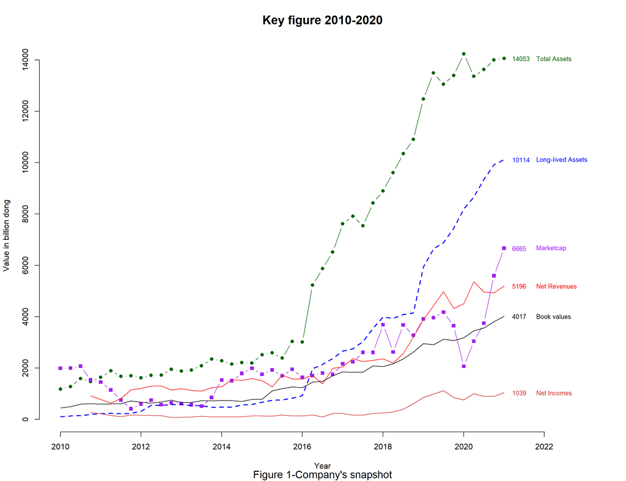

```r
HPG1$A53[HPG1$A53==0]<-NA
plot(ts(HPG1$A53, start = c(x[1],1), frequency = 4),
     type = "b", pch = 16, col = "darkgreen",
     main = "Key figure 2010-2020",
     xlab = "Year",
     ylab = "Value in billion dong", bty ="n",
     xlim = c(x[1], tail(x, 1)),
    ylim = c(min(na.omit(c(HPG1$A53, HPG1$V04, HPG2$IS03, HPG1$A23[length(HPG1$A23)], HPG2$IS22, HPG1$V14))), max(na.omit(c(HPG1$A53, HPG1$V04, HPG2$IS03, HPG1$A23[length(HPG1$A23)], HPG2$IS22, HPG1$V14)))),
     sub ="Figure 1-Company's snapshot",
     cex.main = 1.5,
     cex.sub = 1.3,
     cex.lab = 15,
     cex.axis = 20)
#text(c(tail(x - 1.8, 1), tail(x - 1.8,1) + 0.6), c(as.numeric(HPG1$A53[length(HPG1$A53)]),as.numeric(HPG1$A53[length(HPG1$A53)])),adj=0, c(as.character(round(as.numeric(HPG1$A53[length(HPG1$A53)])),0), "Total Assets"), col = "darkgreen", cex = 0.8)
text(c(tail(x - 1.8, 1), tail(x - 1.8,1) + 0.6), c(as.numeric(HPG1$A53[length(HPG1$A53)]),as.numeric(HPG1$A53[length(HPG1$A53)])),adj=0, c(as.character(round(as.numeric(HPG1$A53[length(HPG1$A53)])),0), "Total Assets"), col = "darkgreen", cex = 0.8)



HPG1$V04[HPG1$V04==0]<-NA
lines(ts(HPG1$V04, start = c(x[1],1), frequency = 4), type = "b",
      pch = 15, col = "purple")
text(c(tail(x - 1.8, 1), tail(x - 1.8,1) + 0.6),c(as.numeric(HPG1$V04[length(HPG1$V04)]),as.numeric(HPG1$V04[length(HPG1$V04)])),adj=0, c(as.character(round(as.numeric(HPG1$V04[length(HPG1$V04)])),0), "Marketcap"), col = "purple", cex = 0.8)

HPG2$IS03[HPG2$IS03==0]<-NA
lines(ts(HPG2$IS03, start = c(x[1],1), frequency = 4), type = "l",
      pch = 15, col = "red", data = HPG2)
text(c(tail(x - 1.8, 1), tail(x - 1.8,1) + 0.6),c(as.numeric(HPG2$IS03[length(HPG2$IS03)]),as.numeric(HPG2$IS03[length(HPG2$IS03)])),adj=0, c(as.character(round(as.numeric(HPG2$IS03[length(HPG2$IS03)])),0), "Net Revenues"), col = "red", cex = 0.8)

HPG1$A23[HPG1$A23==0]<-NA
lines(ts(HPG1$A23, start = c(x[1],1), frequency = 4), type = "l",
      pch = 15, col = "blue", lwd = 2, lty = 2)
text(c(tail(x - 1.8, 1), tail(x - 1.8,1) + 0.6),c(as.numeric(HPG1$A23[length(HPG1$A23)]),as.numeric(HPG1$A23[length(HPG1$A23)])),adj=0, c(as.character(round(as.numeric(HPG1$A23[length(HPG1$A23)])),0), "Long-lived Assets"), col = "blue", cex = 0.8)

HPG2$IS22[HPG2$IS22==0]<-NA
lines(ts(HPG2$IS22, start = c(x[1],1), frequency = 4), type = "l",
      pch = 15, col = "brown3")
text(c(tail(x - 1.8, 1), tail(x - 1.8,1) + 0.6),c(as.numeric(HPG2$IS22[length(HPG2$IS22)]),as.numeric(HPG2$IS22[length(HPG2$IS22)])),adj=0, c(as.character(round(as.numeric(HPG2$IS22[length(HPG2$IS22)])),0), "Net Incomes"), col = "brown3", cex = 0.8)

HPG1$V14[HPG1$V14==0]<-NA
lines(ts(HPG1$V14, start = c(x[1],1), frequency = 4), type = "l",
      pch = 15)
text(c(tail(x - 1.8, 1), tail(x - 1.8,1) + 0.6),c(as.numeric(HPG1$V14[length(HPG1$V14)]),as.numeric(HPG1$V14[length(HPG1$V14)])),adj=0, c(as.character(round(as.numeric(HPG1$V14[length(HPG1$V14)])),0), "Book values"), cex = 0.8)
```

- **Đồ thị 1 đường có chú thích:**

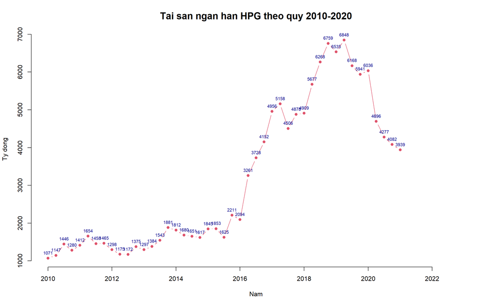

```r
HPG1$A01[HPG1$A01==0]<-NA
plot(ts(HPG1$A01, start = c(x[1],1), frequency = 4),
     type = "b", pch = 16, col = 2, bty = "n",
     xlim = c(x[1], tail(x, 1)),
     ylim = c(min(na.omit(HPG1$A01)), max(na.omit(HPG1$A01))),
     main = "Tai san ngan han HPG theo quy 2010-2020",
     xlab = "Nam", ylab = "Ty dong",
     sub = "",
     cex.main = 1.5,
     cex.sub = 1.3,
     cex.lab = 15,
     cex.axis = 20)
text(time(ts(HPG1$A01, start = c(x[1],1), frequency = 4)),
     ts(HPG1$A01, start = c(x[1],1), frequency = 4),
     labels = as.character(round(HPG1$A01,0)),
     pos = 3, cex = 0.7, col = "darkblue")
```

- **Thêm đường trung bình vào đồ thị**

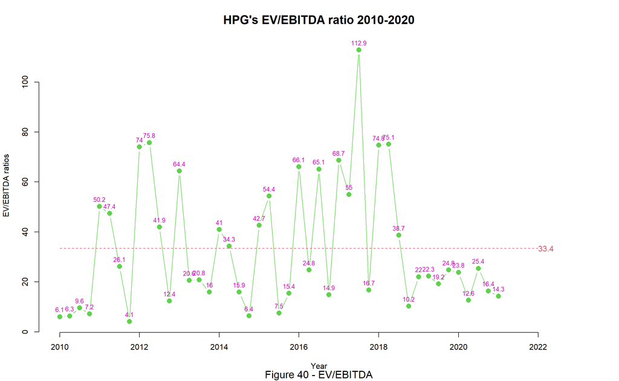

```r
plot(ts(V10, start = c(x[1],1), frequency = 4),
     type = "b", pch = 16, col = 3, cex = 1.4, xlab = "Year",
     ylab = "EV/EBITDA ratios", main = "HPG's EV/EBITDA ratio 2010-2020",
     bty = "n", xlim = c(x[1], tail(x, 1)),
     sub = "Figure 40 - EV/EBITDA",
     cex.main = 1.5,
     cex.sub = 1.3,
     cex.lab = 15,
     cex.axis = 20)
text(time(ts(V10, start = c(x[1],1), frequency = 4)),
     ts(V10, start = c(x[1],1), frequency = 4),
     labels = as.character(round(V10,1)),
     pos = 3, col = 6, cex = 0.8)
segments(2010,mean(na.omit(V10)), 2022,mean(na.omit(V10)), col = 2, lty = 2)
text(2022, mean(na.omit(V10)), adj = 0, round(mean(na.omit(V10)),1), col = 2)
```

## **XIII. Đồ thị với ggplot2**

### *1. Cấu trúc tổng quan*

```
ggplot(data = <Data>, mapping = aes(x = col1, y = col2)) + <goem_function>()
```

- Trong đó:
  - aes là để xác định vùng biểu đồ (Trục x/y)
  - Goem là để định dạng biểu đồ (Cột, đường,…)
    - Histograms – goem_histogram()
    - Biểu đồ cột – goem_col() hoặc goem_bar()
    - Box plots – goem_boxplot()
    - Điểm – goem_point()
    - Biểu đồ đường – goem_line() hoặc goem_path()
    - Đường xu hướng – goam_smooth()
- Có thể hiện thị nhiều goem cùng 1 biểu đồ, nối với nhau bởi dấu “+” và goem sau đc vẽ trồng lên goem trc.
- Mapping để xác định trục của biểu đồ, x là miền khai báo bắt buộc bieeurthij biến cần vẽ được chiwwus theo hệ tọa độ nào, y có thể có hoặc không (Khi y được count tự động)
- Bên trong mỗi goem sẽ có định dạng của goem đang vẽ:
  - shape = : Được sử dụng với goem_point – định dạng hình dnagj của điểm
  - fill = : Tô màu bên trong đồ thị
  - color = : Màu đường bên ngoài của cột, boxplot,… hoặc màu của điểm với goem_point (Có thể gán thành 1 màu cố định hoặc gán theo 1 cột)
  - size = : kích thước đường, điểm,…
  - width = : Độ rộng của các cột trong biểu đồ cột
  - linetype = : Kiểu đường

### *2. Ví dụ thực tế*

#### *a. Basic Bar*

```r
# Library
library(ggplot2)
library(dplyr)

# Dataset 1: one value per group
data <- data.frame(
  name=c("north","south","south-east","north-west","south-west","north-east","west","east"),
  val=sample(seq(1,10), 8 )
)
data
```

```
##         name val
## 1      north   2
## 2      south  10
## 3 south-east   9
## 4 north-west   3
## 5 south-west   8
## 6 north-east   1
## 7       west   5
## 8       east   6
```

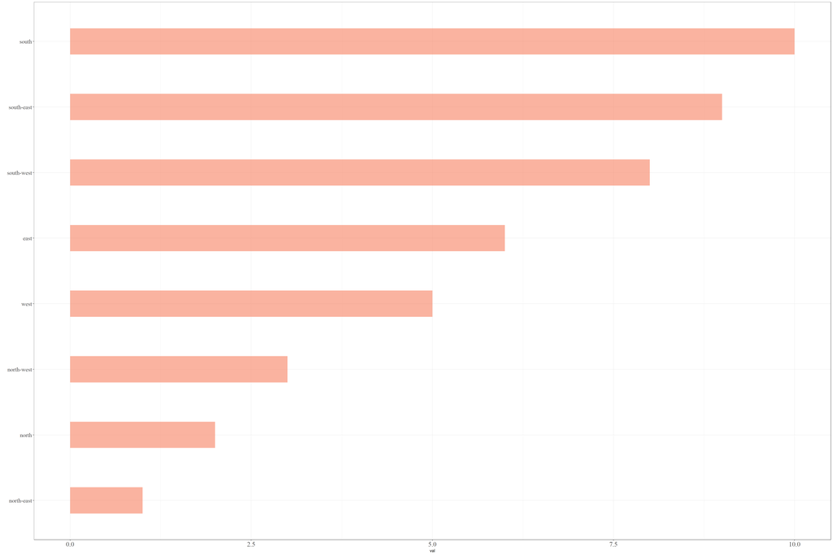

```r
library(forcats)

# Reorder following the value of another column:
data %>%
  mutate(name = fct_reorder(name, val)) %>%
  ggplot( aes(x=name, y=val)) +
    geom_bar(stat="identity", fill="#f68060", alpha=.6, width=.4) +
    coord_flip() +
    xlab("") +
    theme_bw() +
    theme(axis.text.y = element_text(size = 15, family = "serif")) +
    theme(axis.text.x = element_text(size = 17, family = "serif"))
```

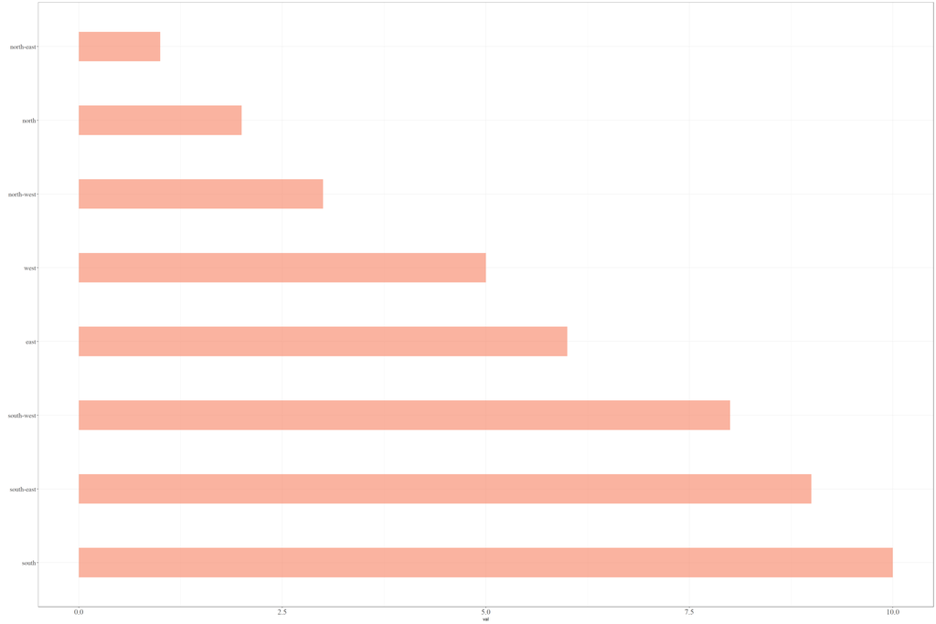

```r
# Reverse side
data %>%
  mutate(name = fct_reorder(name, desc(val))) %>%
  ggplot( aes(x=name, y=val)) +
    geom_bar(stat="identity", fill="#f68060", alpha=.6, width=.4) +
    coord_flip() +
    xlab("") +
    theme_bw() +
    theme(axis.text.y = element_text(size = 15, family = "serif")) +
    theme(axis.text.x = element_text(size = 17, family = "serif"))
```

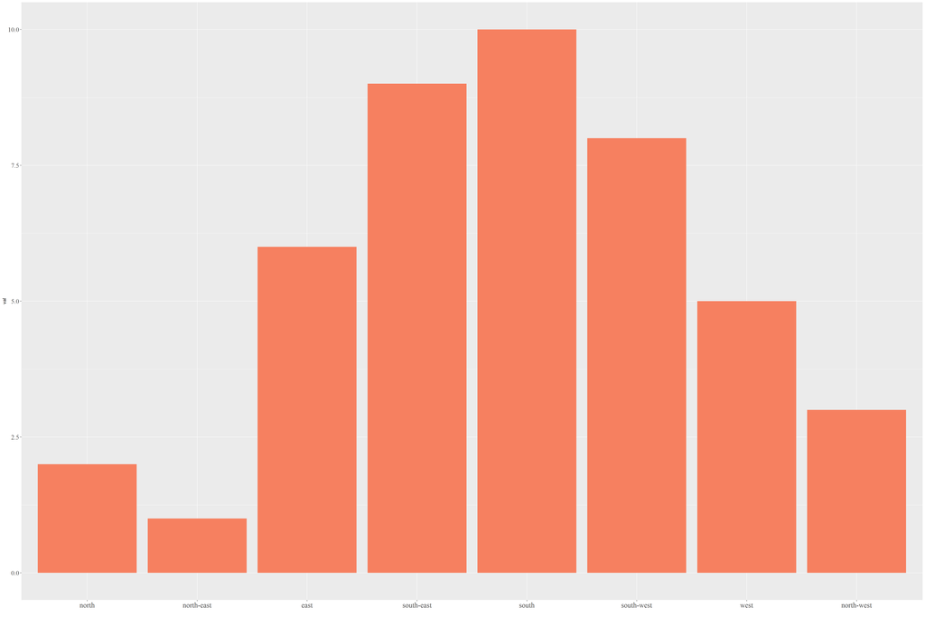

```r
#Bar dọc
data %>%
  mutate(name = fct_relevel(name,
            "north", "north-east", "east",
            "south-east", "south", "south-west",
            "west", "north-west")) %>%
  ggplot( aes(x=name, y=val)) +
    geom_bar(stat="identity", fill="#f68060") +
    xlab("") +
    theme(axis.text.y = element_text(size = 15, family = "serif")) +
    theme(axis.text.x = element_text(size = 17, family = "serif"))
```

#### *b. Bar plot with percentage*

```r
library(readr)
df_data_industry <- read_csv("C:/Users/Nhungnt27/Desktop/RStudio/Data/Giáo trình RStudio/multiple_choice_responses.csv")
df_data_industry <- df_data_industry[-1,]
head(df_data_industry)
```

```
## # A tibble: 6 × 246
##   Time from Start to Finish (secon…¹ Q1    Q2    Q2_OTHER_TEXT Q3    Q4    Q5
##   <chr>                              <chr> <chr> <chr>         <chr> <chr> <chr>
## 1 510                                22-24 Male  -1            Fran… Mast… Soft…
## 2 423                                40-44 Male  -1            India Prof… Soft…
## 3 83                                 55-59 Fema… -1            Germ… Prof… <NA>
## 4 391                                40-44 Male  -1            Aust… Mast… Other
## 5 392                                22-24 Male  -1            India Bach… Other
## 6 470                                50-54 Male  -1            Fran… Mast… Data…
## # ℹ abbreviated name: ¹`Time from Start to Finish (seconds)`
## # ℹ 239 more variables: Q5_OTHER_TEXT <chr>, Q6 <chr>, Q7 <chr>, Q8 <chr>,
## #   Q9_Part_1 <chr>, Q9_Part_2 <chr>, Q9_Part_3 <chr>, Q9_Part_4 <chr>,
## #   Q9_Part_5 <chr>, Q9_Part_6 <chr>, Q9_Part_7 <chr>, Q9_Part_8 <chr>,
## #   Q9_OTHER_TEXT <chr>, Q10 <chr>, Q11 <chr>, Q12_Part_1 <chr>,
## #   Q12_Part_2 <chr>, Q12_Part_3 <chr>, Q12_Part_4 <chr>, Q12_Part_5 <chr>,
## #   Q12_Part_6 <chr>, Q12_Part_7 <chr>, Q12_Part_8 <chr>, Q12_Part_9 <chr>, …
```

```r
df_data_industry[c(3,5,7)] -> df_gender_data_industry
df_gender_data_industry %>%
  filter(!is.na(Q5)) -> df_gender_data_industry

df_gender_data_industry %>%
  rename("Gender" = "Q2",
         "Country" = "Q3",
         "data_industry" = "Q5") ->df_gender_data_industry
head(df_gender_data_industry)
```

```
## # A tibble: 6 × 3
##   Gender Country   data_industry
##   <chr>  <chr>     <chr>
## 1 Male   France    Software Engineer
## 2 Male   India     Software Engineer
## 3 Male   Australia Other
## 4 Male   India     Other
## 5 Male   France    Data Scientist
## 6 Male   India     Data Scientist
```

- Đếm số nam nữ của từng nước:

```r
vector_country <- c("Viet Nam", "China", "Thailand", "France", "India", "Germany",
"Australia", "Russia", "Ukraine", "Pakistan", "Japan", "South Korea", "Brazil",
"Belarus", "Sweden", "Portugal", "Poland", "Indonesia", "Netherlands")


vector_data_indus <- c("Software Engineer", "Business Analyst", "data Analyst", "data Engineer", "data Scientist", "DBA/database Engineer", "Research Scientist", "Software Engineer", "Statistician")

vector_gender <- c("Female", "Male")

df_gender_data_industry %>%
  filter(Gender  %in%  vector_gender,
         data_industry %in% vector_data_indus,
         Country  %in% vector_country) -> df_gender_data_industry1

df_gender_data_industry1[c(1,2)] %>%
  group_by(Country, Gender) %>%
  count() -> df_gender_DA_19
head(df_gender_DA_19)
```

```
## # A tibble: 6 × 3
## # Groups:   Country, Gender [6]
##   Country   Gender     n
##   <chr>     <chr>  <int>
## 1 Australia Female     4
## 2 Australia Male      61
## 3 Belarus   Female     1
## 4 Belarus   Male      15
## 5 Brazil    Female    22
## 6 Brazil    Male     203
```

- Vì dữ liệu đang ở hàng dọc nên khi vẽ xong điền giá trị vào đồ thị thì giá trị nam và nữ sẽ bị trồng vào nhau => tách nam và nữ ra thành 2 cột riêng biệt

```r
library(tidyr)
library(stringr)
df_gender_DA_19 %>%
  spread(key = "Gender", value = "n") %>% #Chia giới tính thành 2 cột nam và nữ với giá trị là cột n
  mutate(rate = Female / (Female + Male)) %>% #Tính cột rate là tỷ lệ nữ trên tổng giới tính
  arrange(rate) %>% #Sắp xếp rate theo thứ tự tăng dần
  mutate(label = round(100*rate, 1)) %>% #Tạo cột label là % nữ và lấy 1 số sau dấu phẩy
  mutate(label = as.character(label)) %>% #Đưa cột label về dạng chữ
  mutate(label = case_when(!str_detect(label, "\\.") ~ paste0(label, ".0"), TRUE ~ label)) %>% #Thêm vào những phần trăm tròn ký tự ".0"
  mutate(label = paste0(label, "%")) %>%  #Thêm ký tự % vào cột label
  mutate(label1 = round(100 - 100*rate, 1)) %>% #Tính tỷ lệ nam (vì muốn điền số vào cả đồ thị bên nam)
  mutate(label1 = as.character(label1)) %>%
  mutate(label1 = case_when(!str_detect(label1, "\\.") ~ paste0(label1, ".0"), TRUE ~ label1)) %>%
  mutate(label1 = paste0(label1, "%")) %>%
  mutate(Country = factor(Country, levels = Country)) -> df_rate
df_rate
```

```
## # A tibble: 19 × 6
## # Groups:   Country [19]
##    Country     Female  Male   rate label label1
##    <fct>        <int> <int>  <dbl> <chr> <chr>
##  1 Sweden           1    19 0.05   5.0%  95.0%
##  2 Australia        4    61 0.0615 6.2%  93.8%
##  3 Belarus          1    15 0.0625 6.2%  93.8%
##  4 Thailand         1    14 0.0667 6.7%  93.3%
##  5 Japan           16   207 0.0717 7.2%  92.8%
##  6 Brazil          22   203 0.0978 9.8%  90.2%
##  7 China           12   108 0.1    10.0% 90.0%
##  8 Poland           7    58 0.108  10.8% 89.2%
##  9 Russia          25   176 0.124  12.4% 87.6%
## 10 France          11    75 0.128  12.8% 87.2%
## 11 Pakistan         8    53 0.131  13.1% 86.9%
## 12 Viet Nam         6    36 0.143  14.3% 85.7%
## 13 Ukraine         10    54 0.156  15.6% 84.4%
## 14 India          174   913 0.160  16.0% 84.0%
## 15 Germany         30   133 0.184  18.4% 81.6%
## 16 Netherlands      8    34 0.190  19.0% 81.0%
## 17 South Korea     12    49 0.197  19.7% 80.3%
## 18 Portugal         9    36 0.2    20.0% 80.0%
## 19 Indonesia       14    30 0.318  31.8% 68.2%
```

```r
df_gender_DA_19 -> df1
```

- Sau đó nối lại vào bộ dữ liệu dọc để giá trị trên và dưới ở cùng một nước là giống nhau => khi biểu thị số lên đồ thị giá trị tùng nhau và giống nhau

```r
df1 %>%
  mutate(Country = factor(Country, levels = df_rate$Country)) -> df1_ordered

df1_ordered
```

```
## # A tibble: 38 × 3
## # Groups:   Country, Gender [38]
##    Country   Gender     n
##    <fct>     <chr>  <int>
##  1 Australia Female     4
##  2 Australia Male      61
##  3 Belarus   Female     1
##  4 Belarus   Male      15
##  5 Brazil    Female    22
##  6 Brazil    Male     203
##  7 China     Female    12
##  8 China     Male     108
##  9 France    Female    11
## 10 France    Male      75
## # ℹ 28 more rows
```

```r
# Prepare for data visualization:

library(extrafont)
```

```r
my_font <- "serif" # Set font.

# Fuction for creating our theme:

my_theme <- function(...) {
  theme_minimal() +
    theme(text = element_text(family = my_font)) +
    theme(plot.margin = unit(rep(0.7, 4), "cm")) +
    theme(plot.background = element_rect(fill = "#EFF2F4", color = NA)) +
    theme(plot.title = element_text(size = 19)) +
    theme(plot.subtitle = element_text(size = 11.7, color = "grey30")) +
    theme(plot.caption = element_text(size = 10, color = "grey30")) +
    theme(axis.text.x = element_text(size = 10.5, color = "grey20")) +
    theme(axis.text.y = element_text(size = 10.5, color = "grey20"))

}
```

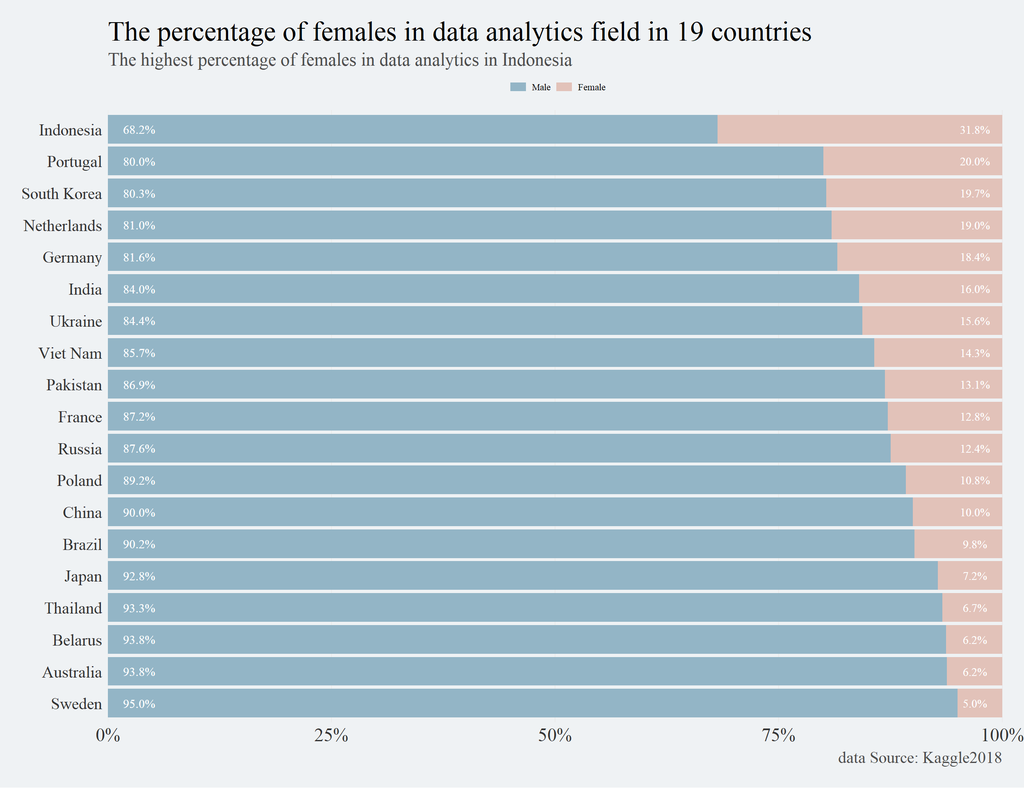

```r
my_colors <- c("#93B5C6", "#E2C2B9")
df1_ordered %>%
  full_join(df_rate, by = "Country") %>%
  ggplot(aes(x = Country, y = n, fill = Gender)) +
  geom_col(position = "fill") +
  coord_flip() +
  geom_text(aes(x = Country, y = 0.97, label = label), size = 3.8, color = "white", family = my_font) +
  geom_text(aes(x = Country, y = 0.035, label = label1), size = 4, color = "white", family = my_font) +
  scale_fill_manual(name = "", values = c(Male = my_colors[1], Female = my_colors[2]), labels = c("Female", "Male")) +
  scale_y_continuous(labels = paste0(seq(0, 100, 25), "%"), expand = c(0, 0)) +
  my_theme() +
  theme(legend.position = "top") +
  guides(fill = guide_legend(reverse = TRUE)) +
  theme(panel.grid.major.y = element_blank(), panel.grid.minor.x = element_blank()) +
  theme(legend.key.height = unit(0.15, "mm"), legend.key.width = unit(5, "mm")) +
  labs(x = NULL, y = NULL,
       title = "The percentage of females in data analytics field in 19 countries",
       subtitle = "The highest percentage of females in data analytics in Indonesia",
       caption = "data Source: Kaggle2018") +
  theme(plot.title = element_text(family = "serif", size = 25)) +
  theme(plot.subtitle = element_text(family = "serif", color = "grey30", size = 17)) +
  theme(plot.caption = element_text(family = "serif", color = "grey30", size = 15)) +
  theme(axis.text.y = element_text(size = 15, family = "serif")) +
  theme(axis.text.x = element_text(size = 17, family = "serif"))
```

**- Bên trong geom:** + shape = : Được sử dụng với goem_point – định dạng hình dnagj của điểm + fill = : Tô màu bên trong đồ thị + color = : Màu đường bên ngoài của cột, boxplot,… hoặc màu của điểm với goem_point (Có thể gán thành 1 màu cố định hoặc gán theo 1 cột) + size = : kích thước đường, điểm,… + width = : Độ rộng của các cột trong biểu đồ cột + linetype = : Kiểu đường **- Format đồ thị:** + coord_flip: Xoay ngang đồ thị + scale_fill_manual: Set màu theo giá trị của biến + scale_y_continuous: Set khoảng giá trị và bước ngảy cho trục (Trục là biến liên tục) + scale_fill_manual(values = c(tập hợp màu)): Thay đổi màu sắc cho đồ thị box, bar,… + scale_color_manual(values = c(tập hợp màu)): Thay đổi màu sắc cho đồ thị line, point,… + Thay đổi dải màu sắc theo giá trị của 1 biến cho biểu đồ điểm: + màu theo độ dốc giữa 2 màu: scale_color_gradient(low = “màu 1”, high = “màu 2” + Phân kỳ gradient: scale_color_gradient2(midpoint = mid, low = “màu 1”, mid = “màu 2”, high = “màu 3”, space = “Lab”) **- Format hộp chú thích:** + Đổi tên chú thích: labs(fill = “x”)

```
scale_fill_discrete(name=“Tên chú thích",
                         breaks=c(“Chú thích 1 old", " Chú thích 2 old "),
                         labels=c (“Chú thích 1 new", " Chú thích 2 new"))
```

**- Theme: element_text(family = “serif”, color = “grey30”, size = 17, face = “bold”) - nếu muốn format và element_blank() - nếu muốn xóa** + plot.title: Format tiêu đề đồ thị + legend.title: Tên chú thích + legend.text: Nội dung chú thích + legend.position = “top” : Vị trí chú thích + legend.position = “none” : Xóa chú thích + axis.text.y : Giá trị trong trục + axis.title.y : Tên trục

#### *c. Nhiều đồ thị bar kết hợp*

```r
library(readxl)
gdt <- read_excel("C:/Users/Nhungnt27/Desktop/RStudio/Data/Giáo trình RStudio/gData_CLKD.xlsx")
gdt <- gdt[-c(64,128,192,256,302),]
gdt$`4`[is.na(gdt$`4`)] <- 0
```

```r
clkd <- read_excel("C:/Users/Nhungnt27/Desktop/RStudio/Data/Giáo trình RStudio/DG_T05_2022.xlsx")
clkd <- clkd[c(2,10,25,37,58,76,79)]
clkd <- clkd[-c(1:6),]
name <- c("CNKT", "VHKT", "DVKT", "TTHT", "GPTH", "ĐTHT", "XDDD")
colnames(clkd) <- name
clkd <- clkd[-c(64:70),]
```

```r
library(tidyverse)
x <- c("CNKT", "Tru", length(colnames(gdt)) - 1)
clkd1 <- gather(clkd, Thang, Tru,  -CNKT)
x -> colnames(clkd1)
```

```r
gdt <- left_join(gdt, clkd1, by = c("CNKT", "Tru"))
```

```r
gdt_tru <- gather(gdt, Thang, DT, -c(Tru, CNKT))
gdt_tru$DT <- as.numeric(gdt_tru$DT)
gdt_tru %>%
  group_by(Thang,Tru) %>%
  summarise(DT = sum(DT)) -> gdt_tru
gdt_tru <- gdt_tru[-c(6,12,18,24,30),]
gdt_tru$Thang <- as.numeric(gdt_tru$Thang)
gdt_tru$so_thang <- ifelse(gdt_tru$Thang == "1", "Tháng 1", ifelse(gdt_tru$Thang == "2", "Tháng 2", ifelse(gdt_tru$Thang == "3", "Tháng 3", ifelse(gdt_tru$Thang == "4", "Tháng 4", "Tháng 5"))))
gdt_tru
```

```
## # A tibble: 31 × 4
## # Groups:   Thang [6]
##    Thang Tru            DT so_thang
##    <dbl> <chr>       <dbl> <chr>
##  1     1 DVKT       28572. Tháng 1
##  2     1 GPTH       69445. Tháng 1
##  3     1 TTHT       86758. Tháng 1
##  4     1 XDDD       13511. Tháng 1
##  5     1 XDDD Total 13511. Tháng 1
##  6     2 DVKT       17116. Tháng 2
##  7     2 GPTH       53000. Tháng 2
##  8     2 TTHT       72422. Tháng 2
##  9     2 XDDD        9483. Tháng 2
## 10     2 XDDD Total 10343. Tháng 2
## # ℹ 21 more rows
```

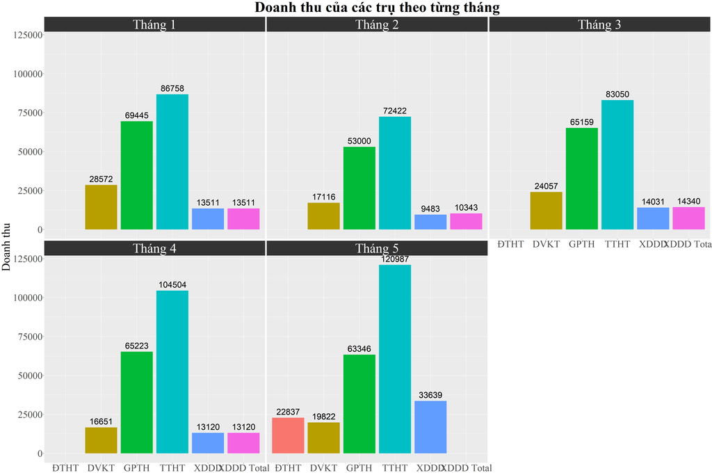

```r
ggplot(gdt_tru, aes(y=DT, fill= Tru, x = Tru)) +
    geom_bar(position="dodge", stat="identity") +
  facet_wrap(~so_thang) +
  geom_text(aes(label = round(DT,0)), vjust = -0.5, colour = "black", size = 9) +
  labs(title = "Doanh thu của các trụ theo từng tháng", fill = "Tỉnh", y = "Doanh thu") +
  theme(
  strip.background = element_rect(fill = "grey20", color = "grey20", size = 20),
  strip.text = element_text(colour = "white", size = 40, family = "serif")
) +
  theme(legend.position = "none") +
 theme(legend.text = element_text(size = 15), legend.title = element_text(size = 30, face = "bold"), legend.key.width = unit(0.8, "cm"), legend.key.height = unit(1, "cm") ) +
  theme(axis.text.y = element_text(size = 30, family = "serif")) +
  theme(axis.text.x = element_text(size = 30, family = "serif")) +
  theme(axis.title.y = element_text(size = 35, family = "serif")) +
  theme(axis.title.x = element_blank()) +
  theme(plot.title = element_text(size = 45, family = "serif", hjust = 0.5, face = "bold"))
```

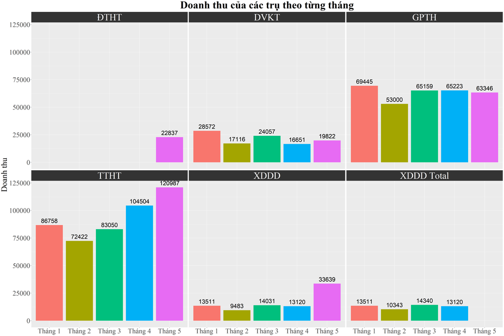

```r
ggplot(gdt_tru, aes(y=DT, fill= so_thang, x = so_thang)) +
    geom_bar(position="dodge", stat="identity") +
  facet_wrap(~Tru) +
  geom_text(aes(label = round(DT,0)), vjust = -0.5, colour = "black", size = 9) +
  labs(title = "Doanh thu của các trụ theo từng tháng", fill = "Tỉnh", y = "Doanh thu") +
  theme(
  strip.background = element_rect(fill = "grey20", color = "grey20", size = 20),
  strip.text = element_text(colour = "white", size = 40, family = "serif")
) +
  theme(legend.position = "none") +
 theme(legend.text = element_text(size = 15), legend.title = element_text(size = 30, face = "bold"), legend.key.width = unit(0.8, "cm"), legend.key.height = unit(1, "cm") ) +
  theme(axis.text.y = element_text(size = 30, family = "serif")) +
  theme(axis.text.x = element_text(size = 30, family = "serif")) +
  theme(axis.title.y = element_text(size = 35, family = "serif")) +
  theme(axis.title.x = element_blank()) +
  theme(plot.title = element_text(size = 45, family = "serif", hjust = 0.5, face = "bold"))
```

#### *d. Multiple bar*

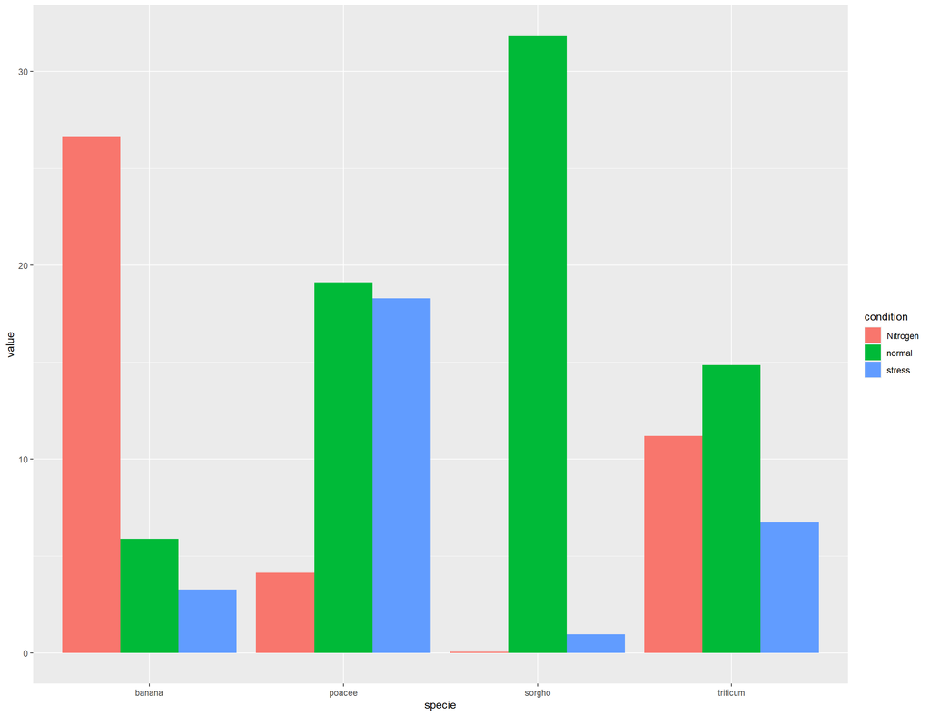

```r
library(ggplot2)

# create a dataset
specie <- c(rep("sorgho" , 3) , rep("poacee" , 3) , rep("banana" , 3) , rep("triticum" , 3) )
condition <- rep(c("normal" , "stress" , "Nitrogen") , 4)
value <- abs(rnorm(12 , 0 , 15))
data <- data.frame(specie,condition,value)

# Grouped
ggplot(data, aes(fill=condition, y=value, x=specie)) +
    geom_bar(position="dodge", stat="identity")
```

#### *e. Đồ thị cột chồng (Stacked barchart)*

```r
library(ggplot2)

# create a dataset
specie <- c(rep("sorgho" , 3) , rep("poacee" , 3) , rep("banana" , 3) , rep("triticum" , 3) )
condition <- rep(c("normal" , "stress" , "Nitrogen") , 4)
value <- abs(rnorm(12 , 0 , 15))
data <- data.frame(specie,condition,value)

# Stacked
ggplot(data, aes(fill=condition, y=value, x=specie)) +
    geom_bar(position="stack", stat="identity")
```

[output not shown]

```r
ggplot(data, aes(fill=condition, y=value, x=specie)) +
    geom_bar(position="fill", stat="identity")
```

[output not shown]

#### *f. Dot plot*

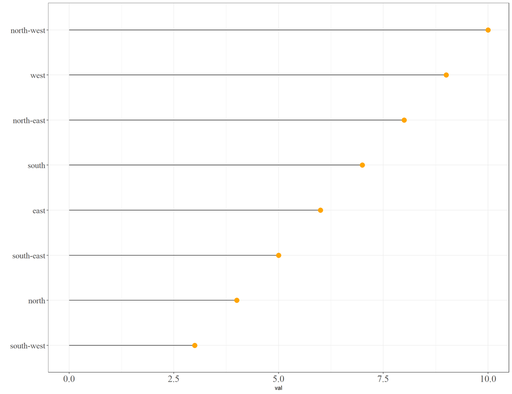

```r
library(ggplot2)
library(dplyr)

# Dataset 1: one value per group
data <- data.frame(
  name=c("north","south","south-east","north-west","south-west","north-east","west","east"),
  val=sample(seq(1,10), 8 )
)
#Ngang
data %>%
  arrange(val) %>%    # First sort by val. This sort the dataframe but NOT the factor levels
  mutate(name=factor(name, levels=name)) %>%   # This trick update the factor levels
  ggplot( aes(x=name, y=val)) +
    geom_segment( aes(xend=name, yend=0)) +
    geom_point( size=4, color="orange") +
    coord_flip() +
    theme_bw() +
    xlab("") +
    theme(axis.text.y = element_text(size = 15, family = "serif")) +
    theme(axis.text.x = element_text(size = 17, family = "serif"))
```

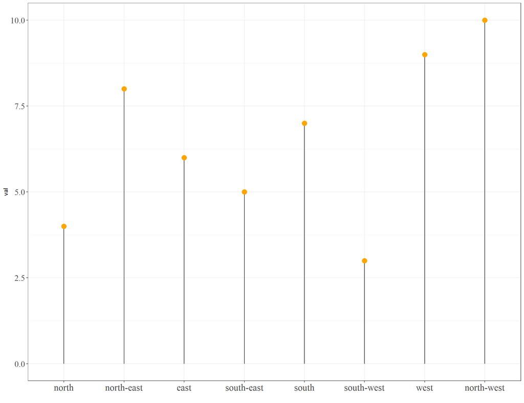

```r
#Dọc
data %>%
  arrange(val) %>%
  mutate(name = factor(name, levels=c("north", "north-east", "east", "south-east", "south", "south-west", "west", "north-west"))) %>%
  ggplot( aes(x=name, y=val)) +
    geom_segment( aes(xend=name, yend=0)) +
    geom_point( size=4, color="orange") +
    theme_bw() +
    xlab("") +
    theme(axis.text.y = element_text(size = 15, family = "serif")) +
    theme(axis.text.x = element_text(size = 17, family = "serif"))
```

#### *g. Highlight 1 dot trong dotplot*

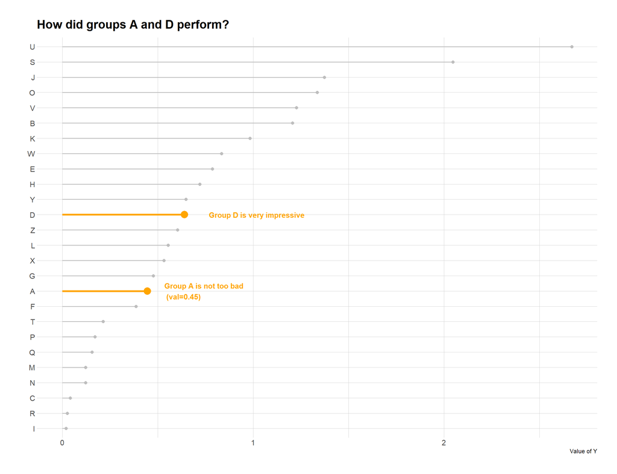

```r
library(ggplot2)
library(dplyr)
library(hrbrthemes)

# Create data
set.seed(1000)
data <- data.frame(
  x=LETTERS[1:26],
  y=abs(rnorm(26))
)

# Reorder the data
data <- data %>%
  arrange(y) %>%
  mutate(x=factor(x,x))

# Plot
p <- ggplot(data, aes(x=x, y=y)) +
  geom_segment(
    aes(x=x, xend=x, y=0, yend=y),
    color=ifelse(data$x %in% c("A","D"), "orange", "grey"),
    size=ifelse(data$x %in% c("A","D"), 1.3, 0.7)
  ) +
  geom_point(
    color=ifelse(data$x %in% c("A","D"), "orange", "grey"),
    size=ifelse(data$x %in% c("A","D"), 5, 2)
  ) +
  theme_ipsum() +
  coord_flip() +
  theme(
    legend.position="none"
  ) +
  xlab("") +
  ylab("Value of Y") +
  ggtitle("How did groups A and D perform?")

# Add annotation
p + annotate("text", x=grep("D", data$x), y=data$y[which(data$x=="D")]*1.2,
           label="Group D is very impressive",
           color="orange", size=4 , angle=0, fontface="bold", hjust=0) +

    annotate("text", x = grep("A", data$x), y = data$y[which(data$x=="A")]*1.2,
           label = paste("Group A is not too bad\n (val=",data$y[which(data$x=="A")] %>% round(2),")",sep="" ) ,
           color="orange", size=4 , angle=0, fontface="bold", hjust=0)
```

#### *h. Line chart basic*

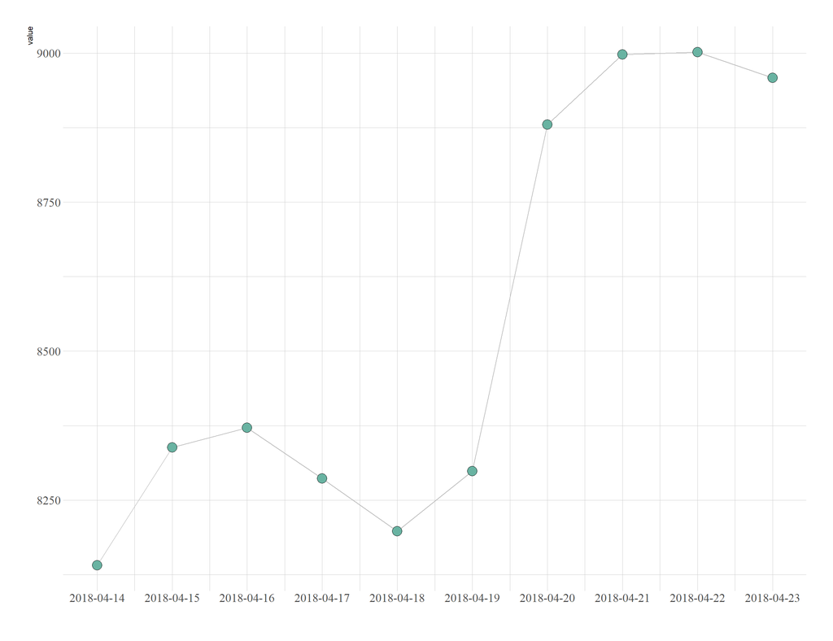

```r
library(ggplot2)
library(dplyr)
library(hrbrthemes)
#Load dataset from github
data <- read.table("https://raw.githubusercontent.com/holtzy/data_to_viz/master/Example_dataset/3_TwoNumOrdered.csv", header=T)
data$date <- as.Date(data$date)

#Plot
data %>%
  tail(10) %>%
  ggplot( aes(x=date, y=value)) +
    geom_line(color="grey") +
    geom_point(shape=21, color="black", fill="#69b3a2", size=5) +
    xlab("") +
    theme_ipsum() +
    scale_x_date(date_breaks = "1 day") + #Hiện full ngày ở trục x
    theme(axis.text.y = element_text(size = 13, family = "serif")) +
    theme(axis.text.x = element_text(size = 13, family = "serif"))
```

#### **_i. Multiple line**

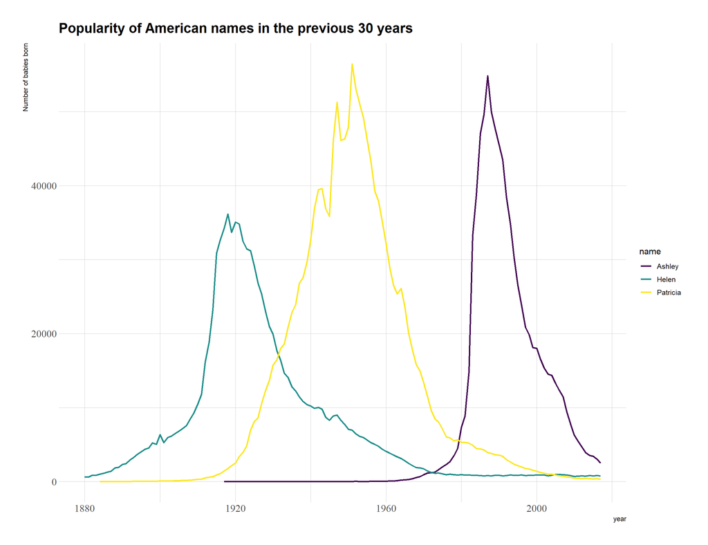

```r
library(ggplot2)
library(babynames) # provide the dataset: a dataframe called babynames
library(dplyr)
library(hrbrthemes)
library(viridis)

# Keep only 3 names
don <- babynames %>%
  filter(name %in% c("Ashley", "Patricia", "Helen")) %>%
  filter(sex=="F")

# Plot
don %>%
  ggplot( aes(x=year, y=n, group=name, color=name)) +
    geom_line(size = 1) +
    scale_color_viridis(discrete = TRUE) +
    ggtitle("Popularity of American names in the previous 30 years") +
    theme_ipsum() +
    ylab("Number of babies born") +
    theme(axis.text.y = element_text(size = 13, family = "serif")) +
    theme(axis.text.x = element_text(size = 13, family = "serif"))
```

#### *j. Donut plot*

```r
library(ggplot2)

# Create test data.
data <- data.frame(
  category=c("A", "B", "C"),
  count=c(10, 60, 30)
)

# Compute percentages
data$fraction <- data$count / sum(data$count)

# Compute the cumulative percentages (top of each rectangle)
data$ymax <- cumsum(data$fraction)

# Compute the bottom of each rectangle
data$ymin <- c(0, head(data$ymax, n=-1))

# Compute label position
data$labelPosition <- (data$ymax + data$ymin) / 2

# Compute a good label
data$label <- paste0(data$category, "\n value: ", data$count)

data
```

```
##   category count fraction ymax ymin labelPosition         label
## 1        A    10      0.1  0.1  0.0          0.05 A\n value: 10
## 2        B    60      0.6  0.7  0.1          0.40 B\n value: 60
## 3        C    30      0.3  1.0  0.7          0.85 C\n value: 30
```

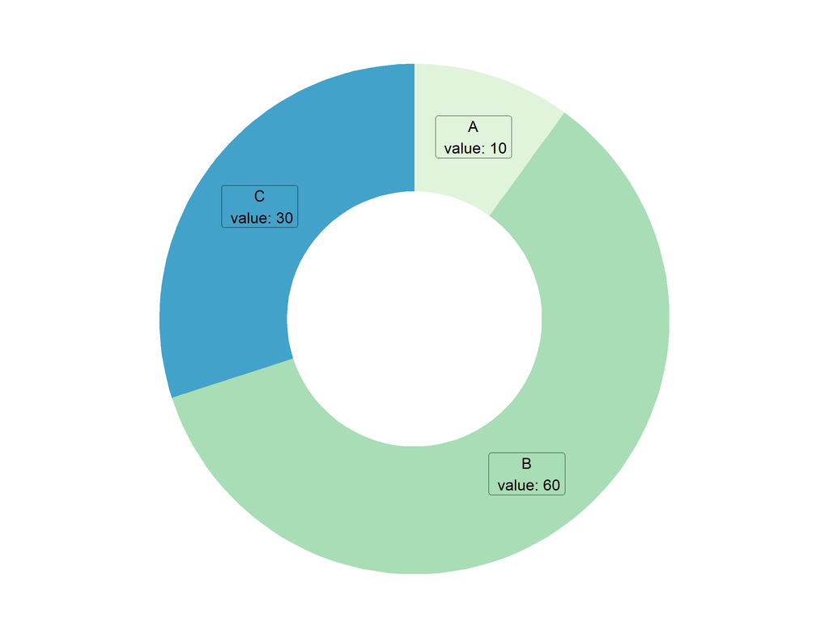

```r
# Make the plot
ggplot(data, aes(ymax=ymax, ymin=ymin, xmax=4, xmin=3, fill=category)) +
  geom_rect() +
  geom_label( x=3.5, aes(y=labelPosition, label=label), size=6) +
  scale_fill_brewer(palette=4) +
  coord_polar(theta="y") +
  xlim(c(2, 4)) +
  theme_void() +
  theme(legend.position = "none")
```

## **X. Đồ thị động với highchartor**

```r
library(readxl)

abc1 <-read_excel("C:/Users/Nhungnt27/Desktop/RStudio/Data/Giáo trình RStudio/RatioQ.xlsx", sheet = 3)
abc1[2:5] <- round(abc1[2:5],2)
abc1
```

```
## # A tibble: 9 × 5
##   Time     Dthu  LNTT   TTS  VCSH
##   <chr>   <dbl> <dbl> <dbl> <dbl>
## 1 2018.Q4  0.13 -0.26  0.48  0.25
## 2 2019.Q1  0.15 -0.17  0.56  0.23
## 3 2019.Q2  0.1  -0.04  0.5   0.21
## 4 2019.Q3  0.06 -0.24  0.39  0.18
## 5 2019.Q4  0.25  0.12  0.3   0.18
## 6 2020.Q1  0.29  0.22  0.26  0.19
## 7 2020.Q2  0.31  0.25  0.21  0.19
## 8 2020.Q3  0.64  0.98  0.21  0.19
## 9 2020.Q4  0.43  1.33  0.29  0.24
```

### *1. Loại 1: Đồ thị đường, hiển thị giá trị theo từng biến*

```r
library(highcharter)


habc <- highchart() %>%
  hc_xAxis(categories = abc1$Time) %>%
  hc_title(text = "Growth Rate",
           margin = 20,
           align = "left",
           style = list(color = "black", fontWeight = "bold")
           ) %>%
  hc_subtitle(text = "Rate (%yoy)",
              align = "left") %>%
  hc_add_series(name = "Total Assets Growth Rate",
                data = abc1$TTS
                ) %>%
  hc_add_series(name = "Equity Growth Rate",
                data = abc1$VCSH
                ) %>%
  hc_colors(c("darkgreen", "darkred"))

habc
```

[interactive chart not shown]

### *2. Loại 2: Đồ thị đường, hiển thị giá trị 2 biến cùng lúc*

```r
habc1 <- habc %>%
  hc_title(text = "Growth Rate",
           margin = 20,
           align = "left",
           style = list(color = "black", fontWeight = "bold")
           ) %>%
  hc_subtitle(text = "Rate (%yoy)",
              align = "left") %>%
  hc_legend(align = "right",
            verticalAlign = "top",
            layout = "vertical",
            x = 0,
            y = 100
            ) %>%
  hc_tooltip(crosshairs = TRUE,
             backgroundColor = "#FCFFC5",
             shared = TRUE,
             borderWidth = 4)

habc1
```

[interactive chart not shown]

### *3. Loại 3: Đồ thị cột, hiển thị giá trị theo từng biến*

```r
habc2 <- highchart() %>%
  hc_chart(type = "column") %>%
  hc_xAxis(categories = abc1$Time) %>%
  hc_title(text = "Growth Rate",
           margin = 20,
           align = "left",
           style = list(color = "black", fontWeight = "bold")
           ) %>%
  hc_subtitle(text = "Rate (%yoy)",
              align = "left") %>%
  hc_series(list(name="Total Assets Growth Rate", data = abc1$TTS),
        list(name="Equity Growth Rate", data = abc1$VCSH)) %>%
  hc_colors(c("darkgreen", "darkred"))

habc2
```

[interactive chart not shown]

## **XI. Làm báo cáo tự động với output dạng html**

### *1. Data*

```r
kq_tru <- read_excel("C:/Users/Nhungnt27/Desktop/RStudio/Data/Giáo trình RStudio/KQSXKD_reactable.xlsx")
```

```r
kq3 <- accounting(unlist(kq_tru[c(1:21),5]), digits = 2L, format = "d", big.mark = ",")
kq4 <- accounting(unlist(kq_tru[c(1:21),6]), digits = 2L, format = "d", big.mark = ",")
kq34 <- round(kq4*100/kq3,2)
kq5 <- accounting(unlist(kq_tru[c(1:21),9]), digits = 2L, format = "d", big.mark = ",")
kq6 <- accounting(unlist(kq_tru[c(1:21),10]), digits = 2L, format = "d", big.mark = ",")
kq7 <- unlist(kq_tru[1])
kq8 <- unlist(kq_tru[2])
kq_tru <- data.frame(kq7, kq8, kq3, kq4, kq34,kq5,kq6)
n <- c("Đơn vị", "Chỉ tiêu", "KH T8/2022", "TH T8/2022","%HT", "So sánh T7/2022 (%)", "So sánh T8/2021 (%)")
colnames(kq_tru) <- n
kq_tru1 <- kq_tru
kq_tru1[1:5] <- lapply(kq_tru1[1:5], as.character)
rownames(kq_tru1) <- NULL
```

### *2. Tạo bảng có trường lọc*

*- Gán data thành dữ liệu dùng chung cho toàn bộ chunk:*

```
shared_data <- SharedData$new(data)
```

*- Tạo bảng có trường lọc basic:*

```
shiny::fluidRow(
  shiny::column(
    8,
    filter_select("name_col1", "Name column 1", shared_data, ~`Name column 1`),
    filter_select("name_col2", "Name column 2", shared_data, ~`Name column 2`)
  ),
  shiny::column(
    8,
    reactable(shared_data, minRows = 4,width = 1200,
  resizable = TRUE,
  wrap = FALSE,
  bordered = TRUE,
  highlight = TRUE,
  defaultSorted = c("Name column 2", "Name column 3"),
  searchable = TRUE,
  defaultPageSize = 4,
  paginationType = "jump",
  columns = list(
    `Name column 3` = colDef(
      aggregate = "mean", align = "right",
      style = JS("function(rowInfo) {
        var value = rowInfo.row[`Name column 3`]
        if (value > 0) {
          var color = '#008000'
        } else if (value < 0) {
          var color = '#e00000'
        } else {
          var color = '#000000'
        }
        return { color: color }
      }")),
    `Name column 4` = colDef(
      aggregate = "mean", align = "right", width = 100)
  )
)))
```

- Trong đó:
  - Name column 1 và Name column 2 là tên các cột muốn để làm trường lọc
  - name_col1 và name_col2 là tên viết liền không dấu của cột để làm trường lọc
  - width: Chiều rộng của cả bảng
  - wrap: Chức năng Wrap text như trong excel
  - resizable:
  - bordered: Kẻ khung cho bảng
  - highlight: Bôi đen hàng khi di chuột qua
  - defaultSorted: Thêm chức năng sort các cột được chỉ định
  - searchable: Thêm ô search kèm bảng (Phải gõ chữ cần tìm kiếm)
  - defaultPageSize: Chức năng phân trang cho bảng (defaultPageSize = 4 => hiện 4 hàng 1 trang)
  - minRows: Đặt số hàng tối thiểu trên 1 trang (Hữu ích khi các hàng không lấp đầy trang hoặc bảng có bộ lọc)
  - paginationType: Tạo tính năng chọn trang muốn đến
    - “jump”để hiển thị một trang nhảy
    - “simple”để chỉ hiển thị các nút trước đó/tiếp theo
  - defaultColDef = colDef(sortNALast = TRUE): Những giá trị NA thì để ô trống
  - Format từng cột:
    - align: “right”, “left”, “center” => căn cột
    - width: Chiều rộng của cột

Đơn vị

Chỉ tiêu

| Đơn vị | Chỉ tiêu | KH T8/2022 | TH T8/2022 | %HT | So sánh T7/2022 (%) | So sánh T8/2021 (%) |
| --- | --- | --- | --- | --- | --- | --- |
| TCT | Nguồn việc | 1,168,996 | 1,033,893 | 88 | 3.72 | 24.23 |
| VHKT | Nguồn việc | 336,233 | 340,576 | 101 | -0.15 | 6.83 |
| DVKT | Nguồn việc | 63,728 | 12,908 | 20 | -6.12 | -8.71 |
| TTHT | Nguồn việc | 146,327 | 145,823 | 99 | 8.47 | 6.11 |
| GPTH | Nguồn việc | 242,270 | 89,288 | 36 | -7.25 | 39.52 |
| XDDD | Nguồn việc | 132,055 | 135,000 | 102 | 3.85 | 42.11 |
| ĐTHT | Nguồn việc | 91,564 | 105,147 | 114 | 9.18 | 501.36 |
| TCT | Sản lượng | 1,120,560 | 837,791 | 74 | 2.43 | 15.53 |
| VHKT | Sản lượng | 336,233 | 340,576 | 101 | -0.15 | 6.83 |
| DVKT | Sản lượng | 33,127 | 12,908 | 38 | -6.12 | -8.71 |

[output cut: 11 more lines]

### *3. Tạo bảng có theo group*

#### *a. Dòng group không có giá trị*

| Đơn vị | Chỉ tiêu | KH T8/2022 | TH T8/2022 | %HT | So sánh T7/2022 (%) | So sánh T8/2021 (%) |
| --- | --- | --- | --- | --- | --- | --- |
| TCT | Nguồn việc | 1,168,996 | 1,033,893 | 88 | 3.72 | 24.23 |
| VHKT | Nguồn việc | 336,233 | 340,576 | 101 | -0.15 | 6.83 |
| DVKT | Nguồn việc | 63,728 | 12,908 | 20 | -6.12 | -8.71 |
| TTHT | Nguồn việc | 146,327 | 145,823 | 99 | 8.47 | 6.11 |
| GPTH | Nguồn việc | 242,270 | 89,288 | 36 | -7.25 | 39.52 |
| XDDD | Nguồn việc | 132,055 | 135,000 | 102 | 3.85 | 42.11 |
| ĐTHT | Nguồn việc | 91,564 | 105,147 | 114 | 9.18 | 501.36 |
| TCT | Sản lượng | 1,120,560 | 837,791 | 74 | 2.43 | 15.53 |
| VHKT | Sản lượng | 336,233 | 340,576 | 101 | -0.15 | 6.83 |
| DVKT | Sản lượng | 33,127 | 12,908 | 38 | -6.12 | -8.71 |

[output cut: 11 more lines]

#### *b. Dòng group có hiển thị nội dung*

- Muốn hiển thị nội dung ở dòng group, thêm hàm aggregate tại mỗi cột
  - max/min: hiển thị giá trị max/min của cột trong nhóm đó (Sử dụng với biến num)
  - mean: hiển thị giá trị mean của cột trong nhóm đó (Sử dụng với biến num)
  - sum: hiển thị giá trị sum của cột trong nhóm đó (Sử dụng với biến num)
  - median: hiển thị giá trị median của cột trong nhóm đó (Sử dụng với biến num)
  - count: hiển thị giá trị count của cột trong nhóm đó
  - unique: hiển thị full giá trị trong biến ko có duplicate (Sử dụng với biến định tính)
  - frequency: hiển thị các giá trị trong biến kèm tần suất xuất hiện (Sử dụng với biến định tính)

```r
data <- MASS::Cars93[14:38, c("Type", "Price", "MPG.city", "DriveTrain", "Man.trans.avail")]

reactable(
  data,
  groupBy = "Type",
  columns = list(
    Price = colDef(aggregate = "max"),
    MPG.city = colDef(aggregate = "mean", format = colFormat(digits = 1)),
    DriveTrain = colDef(aggregate = "unique"),
    Man.trans.avail = colDef(aggregate = "frequency")
  )
)
```

| Type | Price | MPG.city | DriveTrain | Man.trans.avail |
| --- | --- | --- | --- | --- |
| Sporty | 15.1 | 19 | Rear | Yes |
| Midsize | 15.9 | 21 | Front | No |
| Van | 16.3 | 18 | Front | No |
| Van | 16.6 | 15 | 4WD | No |
| Large | 18.8 | 17 | Rear | No |
| Sporty | 38 | 17 | Rear | Yes |
| Large | 18.4 | 20 | Front | No |
| Compact | 15.8 | 23 | Front | No |
| Large | 29.5 | 20 | Front | No |
| Small | 9.2 | 29 | Front | Yes |

[output cut: 15 more lines]

#### *c. Multiple group*

```r
data <- data.frame(
  State = state.name,
  Region = state.region,
  Division = state.division,
  Area = state.area
)

reactable(
  data,
  groupBy = c("Region", "Division"),
  columns = list(
    Division = colDef(aggregate = "unique"),
    Area = colDef(aggregate = "sum", format = colFormat(separators = TRUE, suffix = " m\u00b2"))
  ),
  bordered = TRUE
)
```

| State | Region | Division | Area |
| --- | --- | --- | --- |
| Alabama | South | East South Central | 51609 |
| Alaska | West | Pacific | 589757 |
| Arizona | West | Mountain | 113909 |
| Arkansas | South | West South Central | 53104 |
| California | West | Pacific | 158693 |
| Colorado | West | Mountain | 104247 |
| Connecticut | Northeast | New England | 5009 |
| Delaware | South | South Atlantic | 2057 |
| Florida | South | South Atlantic | 58560 |
| Georgia | South | South Atlantic | 58876 |

[output cut: 40 more lines]

- Trong đó với colFormat:
  - separators = TRUE để thêm dấu phân cách hàng nghìn
  - suffix để thêm tiền tố cạnh giá trị
  - “0b2” đặt mũ 2
  - percent = TRUE: Hiển thị dấu %
  - digits = n: hiện n số thập phân sau dấu phẩy
  - date = TRUE: Hiển thị date dưới dạng 2/1/1999
  - date = TRUE, locales = “en-GB”: Hiển thị date dưới dạng 02/01/1999

### *4. Định dạng tiền tệ*

```r
data <- data.frame(
  USD = c(12.12, 2141.213, 0.42, 1.55, 34414),
  EUR = c(10.68, 1884.27, 0.37, 1.36, 30284.32),
  INR = c(861.07, 152122.48, 29.84, 110, 2444942.63),
  JPY = c(1280, 226144, 44.36, 164, 3634634.61),
  MAD = c(115.78, 20453.94, 4.01, 15, 328739.73)
)

reactable(data, columns = list(
  USD = colDef(
    format = colFormat(currency = "USD", separators = TRUE, locales = "en-US")
  ),
  EUR = colDef(
    format = colFormat(currency = "EUR", separators = TRUE, locales = "de-DE")
  ),
  INR = colDef(
    format = colFormat(currency = "INR", separators = TRUE, locales = "hi-IN")
  ),
  JPY = colDef(
    format = colFormat(currency = "JPY", separators = TRUE, locales = "ja-JP")
  ),
  MAD = colDef(
    format = colFormat(currency = "MAD", separators = TRUE, locales = "ar-MA")
  )
))
```

| USD | EUR | INR | JPY | MAD |
| --- | --- | --- | --- | --- |
| 12.12 | 10.68 | 861.07 | 1280 | 115.78 |
| 2141.213 | 1884.27 | 152122.48 | 226144 | 20453.94 |
| 0.42 | 0.37 | 29.84 | 44.36 | 4.01 |
| 1.55 | 1.36 | 110 | 164 | 15 |
| 34414 | 30284.32 | 2444942.63 | 3634634.61 | 328739.73 |

### *5. Định dạng mising value*

```r
reactable(
  data.frame(
    n = c(1, 2, NA, 4, 5),
    x = c(55, 27, NA, NaN, 19),
    y = c(1, NA, 0.25, 0.55, NA)
  ),
  columns = list(
    x = colDef(na = "–", format = colFormat(prefix = "$")),
    y = colDef(na = "NA", format = colFormat(percent = TRUE))
  )
)
```

| n | x | y |
| --- | --- | --- |
| 1 | 55 | 1 |
| 2 | 27 | NA |
| NA | NA | 0.25 |
| 4 | NaN | 0.55 |
| 5 | 19 | NA |

### *6. Thêm ký hiệu đặc biệt kèm value*

```r
data <- MASS::Cars93[1:5, c("Manufacturer", "Model", "Type", "AirBags", "Price")]

reactable(data, columns = list(
  Model = colDef(cell = function(value, index) {
    # Render as a link
    url <- sprintf("https://wikipedia.org/wiki/%s_%s", data[index, "Manufacturer"], value)
    htmltools::tags$a(href = url, target = "_blank", as.character(value))
  }),
  AirBags = colDef(cell = function(value) {
    # Render as an X mark or check mark
    if (value == "None") "\u274c No" else "\u2714\ufe0f Yes"
  }),
  Price = colDef(cell = function(value) {
    # Render as currency
    paste0("$", format(value * 1000, big.mark = ","))
  })
))
```

| Manufacturer | Model | Type | AirBags | Price |
| --- | --- | --- | --- | --- |
| Acura | Integra | Small | None | 15.9 |
| Acura | Legend | Midsize | Driver & Passenger | 33.9 |
| Audi | 90 | Compact | Driver only | 29.1 |
| Audi | 100 | Midsize | Driver & Passenger | 37.7 |
| BMW | 535i | Midsize | Driver only | 30 |

- Note ký hiệu:

```
  + "\u0394" : delta
  + "\u274c" : Dấu X đỏ
  + \u2714\ufe0f : Dấu tick xanh
  + \ue000 : Ô vuông rỗng
  + \u00B0 : Độ
  + \u03A9 : Omega
  + \u03C3 : Sigma
  + \u03BB : lamda
  + \u03C0 ; pi
  + \u03B1 : alpha
  + \u03B2 : beta
(https://pythonforundergradengineers.com/unicode-characters-in-python.html)
  + \u2705 : Ô vuông tick xanh
  + \u2753 : Dấu hỏi đỏ
  + \u279C : Dấu suy ra
  + \u27A4 : Dấu mũi tên
  + \u2B06 : tăng
  + \u2B07 : Giảm
  + \u007E : Xấp sỉ
  + \u00D8 : Rỗng
  + \u0097 : Ngang
```

### *7. Đổi background color*

```r
options(reactable.theme = reactableTheme(
  color = "hsl(233, 9%, 87%)",
  backgroundColor = "hsl(233, 9%, 19%)",
  borderColor = "hsl(233, 9%, 22%)",
  stripedColor = "hsl(233, 12%, 22%)",
  highlightColor = "hsl(233, 12%, 24%)",
  inputStyle = list(backgroundColor = "hsl(233, 9%, 25%)"),
  selectStyle = list(backgroundColor = "hsl(233, 9%, 25%)"),
  pageButtonHoverStyle = list(backgroundColor = "hsl(233, 9%, 25%)"),
  pageButtonActiveStyle = list(backgroundColor = "hsl(233, 9%, 28%)")
))

reactable(
  iris[1:30, ],
  filterable = TRUE,
  showPageSizeOptions = TRUE,
  striped = TRUE,
  highlight = TRUE,
)
```

| Sepal.Length | Sepal.Width | Petal.Length | Petal.Width | Species |
| --- | --- | --- | --- | --- |
| 5.1 | 3.5 | 1.4 | 0.2 | setosa |
| 4.9 | 3 | 1.4 | 0.2 | setosa |
| 4.7 | 3.2 | 1.3 | 0.2 | setosa |
| 4.6 | 3.1 | 1.5 | 0.2 | setosa |
| 5 | 3.6 | 1.4 | 0.2 | setosa |
| 5.4 | 3.9 | 1.7 | 0.4 | setosa |
| 4.6 | 3.4 | 1.4 | 0.3 | setosa |
| 5 | 3.4 | 1.5 | 0.2 | setosa |
| 4.4 | 2.9 | 1.4 | 0.2 | setosa |
| 4.9 | 3.1 | 1.5 | 0.1 | setosa |

[output cut: 20 more lines]

### *8. Link format reactable*

https://glin.github.io/reactable/articles/examples.html#basic-usage

## **XII. Shiny app**

- Bước 1: Mở Rmarkdown, chọn shiny
- Bước 2: Lưu các file excel muốn lấy dữ liệu vào shiny thành file rds (Code sang 1 file code khác)

```
dt_tt_t12 <- read_excel("E:/Nhung/R Studio/Data/Viettel/PLI_Giao Chi tieu T12-2022 CHỐT.xlsx")
saveRDS(dt_tt_t12, file = "dt_tru_t7.rds")
```

- Bước 3: Tạo ui và server
- Bước 4: Tạo tài khoản shinyapps.io để làm output
  - Truy cập link shinyapps.io
  - Tạo tài khoản bằng gmail
  - Chọn Account -> Token -> Show -> Show secret -> Copy to clipboard -> OK
- Bước 5: Trở lại R paste token vào ô console vào run
- Bước 6: chọn biểu tượng mắt xanh bên trái màn hình trong tab code shiny
- Bước 6: Chọn Publish just this document => Publish always

### *1. Ui*

#### *1.1Tạo tính năng tải file:*

```
csvDownloadButton <- function(id, filename = "data.csv", label = "Download as CSV") {
  tags$button(
    tagList(icon("download"), label),
    onclick = sprintf("Reactable.downloadDataCSV('%s', '%s')", id, filename)
  )
}
```

#### *1.2. Cấu trúc tạo ui:*

- Cấu trúc:

```
ui <- dashboardPage(
  dashboardHeader(title = "Tiêu đề báo cáo", titleWidth = 180
  ),
  dashboardSidebar(width = 180,
                   collapsed = TRUE,
                   uiOutput("typ"),
                   sidebarMenu(id ="tab",
                               hr(),
                               menuItem("Tên tab 1", tabName = "ten_tab_1", icon = icon("search")),
                               menuItem("Tên tab 2", tabName = "ten_tab_2", icon = icon("plus-square"))
                   )
  ),

  dashboardBody(
    tags$head(tags$style(
      HTML('.content {
           font-size: 1.6em;
           }
           #.skin-blue .main-header .logo {
           #                     background-color: blue;
           #}
           #.skin-blue .main-header .navbar {
           #                     background-color: blue;
           #                     }
           ')
    )),
    tabItems(
            tabItem("ten_tab_1",
                    tabBox(title = "Tên tab 1" , width = 12,
                          tabPanel(width = 12,style = "overflow-y:scroll; max-height: 1000px; position:relative;", title = "Tên sheet 1", style = "font-family: 'Source Sans Pro'"
                              ,    fluidRow(
                                box(width = 12, height = 580,
                                    uiOutput("data1_ui"),
                                    title = "Tiêu đề bảng 1", status = "primary", solidHeader = TRUE,
                                    csvDownloadButton("data1", filename = "data1.csv"),
                                    reactableOutput("data1")
                                    )
                                            ),
                                   fluidRow(
                                box(width = 10, height = 450,
                                    uiOutput("data_plot1_ui"),
                                    title = "Tiêu đề đồ thị", status = "primary", solidHeader = TRUE,
                                    highchartOutput("data_plot1")
                                    ),
                                box(radioButtons("col1_Colfilter",label = "Tiêu đề cho khung filter", choices = unique(data_plot1$dcol1_Colfilter), selected = "Giá trị hiển thị khi chưa chọn"), width = 2))
                                ),
                          tabPanel(width = 12,style = "overflow-y:scroll; max-height: 1000px; position:relative;", title = "Tên sheet 2", style = "font-family: 'Source Sans Pro'"
                              ,    fluidRow(
                                box(width = 12, height = 930,
                                    uiOutput("data2_ui"),
                                    title = "Tiêu đề bảng 2", status = "primary", solidHeader = TRUE,
                                    csvDownloadButton("data2", filename = "data2.csv"),
                                    reactableOutput("data2")
                                )
                              ))
                              )
            tabItem("ten_tab_2",
              tabBox(title = "Tên tab 2" , width = 12,
                     tabPanel(width = 12, style = "overflow-y:scroll; max-height: 1000px; position:relative;", title = "Tên sheet 1", style = "font-family: 'Source Sans Pro'"
                              ,    fluidRow(
                                box(width = 5, height = 930,
                                    uiOutput("dt_map_ui"),
                                    title = "Tiêu đề map", status = "primary", solidHeader = TRUE,
                                    girafeOutput("dt_map", height = '880px')
                                )
              ))
    )))
```

#### *1.3. Chi tiết các cấu phần của ui:*

- dashboardPage : Function tạo cả page báo cáo
- dashboardHeader : Format thanh tiêu đề báo cáo
  - title : Tiêu đề báo cáo
  - titleWidth : Chiều rộng của khung tiêu đề
- dashboardSidebar : Format khung mục lục
  - width : Chiều rộng khung mục lục
  - collapsed = TRUE => Ẩn khung mục lục, collapsed = FALSE => Hiện khung mục lục
  - sidebarMenu : Set nội dung mục lục
    - menuItem: Format từng nội dung mục lục, bao gồm:
      - Tên nội dung
      - tabName: Tên nội dung viết tắt liền không dấu
      - icon = icon(“name kí hiệu”) : Tên ký hiệu lấy theo link https://fontawesome.com/search?s=light&f=sharp&o=r
- dashboardBody : Format nội dung
  - Format khung tên bảng/đồ thị/map:  
    ~~~ tags$head(tags$style( HTML(‘.content { font-size: 1.6em; } #.skin-blue .main-header .logo { # background-color: blue; #} #.skin-blue .main-header .navbar { # background-color: blue; # }’) )) ~~~
  - tabItem : ~~~ tabItems( tabItem(“ten_tab_1”, tabBox(title = “Tên tab 1” , width = 12, tabPanel(width = 12,style = “overflow-y:scroll; max-height: 1000px; position:relative;”, title = “Tên sheet 1”, style = “font-family: ‘Source Sans Pro’” , fluidRow(box()), fluidRow( box(), box() ) ) tabPanel(width = 12,style = “overflow-y:scroll; max-height: 1000px; position:relative;”, title = “Tên sheet 2”, style = “font-family: ‘Source Sans Pro’” , fluidRow( box() )) ) ~~~
    - ten_tab_1: Tên tab viết liền ko dấu đặt tại dashboardSidebar
    - tabBox: Format cả tab
      - title: Tên hiển thị trên tab
      - width: Chiều dài chung cho tất cả các sheet trong tab
      - tabPanel: các sheet trong 1 tab
        - style = “overflow-y:scroll; max-height: 1000px; position:relative;”, style = “font-family: ‘Source Sans Pro’” : Format font chữ trong sheet
        - title = “Tên sheet 1” ; tên sheet - đặt ngắn gọn giống tên sheet trong excel
        - fluidRow : Các fluidRow trong tabPanel cho phép sắp xếp các bảng/đồ thị theo chiều dọc.
        - box : Các box trong fluidRow cho phép hiển thị các bảng/đồ thị/bộ lọc theo chiều ngang

#### *1.4. Các loại box*

- Nếu output dạng bảng:

```
box(width = 12, height = 580,
    uiOutput("data_ui"),
    title = "Kết quả SXKD trụ tháng 1", status = "primary", solidHeader = TRUE,
    csvDownloadButton("data", filename = "data.csv"),
    reactableOutput("data")
    )
```

- width chiều dài của box
- height chiều rộng của box
- uiOutput(“data_ui”) : data_ui là tên data kèm theo đuôi _ui => để làm ổ chứa nhận diện data khi gọi ở server
- title : Tên bảng/đồ thị
- status : Set màu nền cho khung tên đồ thị
  - primary : Blue (sometimes dark blue)
  - success : Green
  - info : Blue
  - warning : Orange
  - danger : Red
- solidHeader = TRUE : Chỉ định tiêu đề được hiển thị đồng màu với background
- csvDownloadButton : Tạo nút tải dữ liệu cho bảng
- reactableOutput : Định dạng đầu ra dạng bảng
- Nếu output là highchartor:

```
box(width = 10, height = 450,
   uiOutput("data_high_ui"),
   title = "Tên highchart", status = "primary", solidHeader = TRUE,
   highchartOutput("data_high")
   )
```

- Nếu output là ggplot2/map có add tooltip:

```
box(width = 5, height = 930,
    uiOutput("dt_map_ui"),
    title = "Tên map", status = "primary", solidHeader = TRUE,
    girafeOutput("dt_map", height = '880px')
    )
```

- Set output cho bộ lọc kèm đồ thị động:
  - Bộ lọc dạng chọn 1 lựa chọn:

  ```
  box(radioButtons("col",label = "Name col", choices = unique(data_high$col), selected = "value_key"), width = 2)
  ```

  - col: tên cột muốn đặt làm bộ lọc
  - label : Tên khung lọc
  - selected = “value_key” ; value_key là giá trị mặc định lọc khi chưa click chọn giá trị nào
  - Chọn nhiều lựa chọn:

  ```
  box(checkboxGroupInput("col",label = "Name col", choices = unique(data_high$col), selected = "value_key"), width = 2)
  ```

  - Bộ lọc dạng thanh gọn hiển thị list khi click

  ```
  box(selectInput("col",label = "Name col", choices = unique(data_high$col), selected = "value_key"), width = 2)
  ```

  - Bộ lọc là thanh kéo vùng giá trị

  ```
  box(sliderInput("col",label = "Name col", min = 0, max = 1000, value = c(200, 700), step = 100, pre = "$"), width = 2)
  ```

  - min : giá trị min của trục
  - max : giá trị max của trục
  - value : Khoảng giá trị mặc định hiển thị
  - step : Bước nhảy các giá trị trên trục
  - pre : Đơn vị đặt trước giá trị của trục
  - post : Đơn vị được đặt sau giá trị của trục
  - sep = “,” : Dấu phân tách hàng nghìn
  - Thanh kéo cho date:

  ```
  box(sliderInput("col",label = "Name col", min = as.Date("2019-08-09"), max = as.Date("2019-08-16"), value = as.Date("2019-08-10")), width = 2)
  ```

  - Bộ lọc dạng date range:

  ```
  dateRangeInput("col", "Name filter",
                 start  = "2001-01-01",
                 end    = "2010-12-31",
                 min    = "2001-01-01",
                 max    = "2012-12-21",
                 format = "mm/dd/yy",
                 separator = " - ")
  ```

  - start : Ngày bắt đầu mặc định hiển thị (Nếu đặt là NULL sẽ mặc định hiển thị là ngày hôm nay)
  - end : Ngày kết thúc mặc định hiển thị (Nếu đặt là NULL sẽ mặc định hiển thị là ngày hôm nay)
  - min/max ; Ngày tối thiểu/tối đa cho phép chọn
  - format : Định dạng ngày hiển thị
  - separator : Ký tự ngăn cách giữa hộp start và end
  - Hàm lấy ngày hiện tại: Sys.Date() https://curso-r.github.io/my-first-dashboard-with-shiny-csds2019/#52

### *2. Server*

- Cấu trúc chung:

```
server <- function(input, output,session) {
  output$data
  output$data_high
  output$data_map
  output$data_gglot2
}
```

#### *2.1. Format Output dạng bảng*

- Ứng với Ui đặt là reactableOutput
- Cấu trúc:

```
output$kq_tru_t11x <- renderReactable({
  reactable(kq_tru_t11x, minRows = 7,width = 1280, height = 450,
  resizable = TRUE,
  wrap = FALSE,
  bordered = TRUE,
  highlight = TRUE,
  defaultSorted = c("%HT", "KH T1/2022", "TH T1/2022", "So sánh T1/2021 (%)", "So sánh T12/2021 (%)", "Đơn vị"),
  searchable = TRUE,
  striped = TRUE,
  columns = list(
    `So sánh T1/2021 (%)` = colDef(
      aggregate = "mean", align = "right", width = 250,
      style = JS("function(rowInfo) {
        var value = rowInfo.row[`So sánh T1/2021 (%)`]
        if (value > 0) {
          var color = 'green'
        } else if (value < 0) {
          var color = 'red'
        } else {
          var color = 'black'
        }
        return { color: color }
      }")))
```

- Trong đó: reactable như chương reactable bên trên

#### *2.2. Format Output dạng highchartor*

- Cấu trúc:

```
output$plot_tru_t12x <- renderHighchart({
      plot_tru_t12x %>%
filter(don_vi == input$don_vi) %>%
hchart("line", hcaes(x = date, y = round(doanh_thu,2), group = don_vi),
       regression = TRUE,
       regressionSettings = list(
    type = "polynomial",
    dashStyle = "ShortDash",
    color = "#990000",
    order = 3,
    lineWidth = 3,
    name = "",
    hideInLegend = TRUE)) %>%
      hc_add_dependency("plugins/highcharts-regression.js") %>%
  hc_subtitle(text = "Triệu đồng",
              align = "left") %>%
  hc_title(text = "Tăng trưởng doanh thu 2021-2022",
           margin = 20,
           align = "left",
           style = list(color = "black", fontWeight = "bold")
           ) %>%
      hc_xAxis(title = list(text = "Date")) %>%
  hc_yAxis(title = list(text = "Doanh thu")) %>%
  hc_colors(c("darkgreen", "darkred", "#FF9900", "#0066FF", "#663300", "#000077"))
  })
```

- Trong đó:
  - filter(don_vi == input$don_vi): tương ứng với cột được gọi trong radioButtons ở Ui
  - hchart: Vẽ giống chương đồ thị động

#### *2.3. Format Output ggplot2*

```
output$dt_map1 <- renderGirafe({
    a <- ggplot(dt_map1, aes(fill=KI, y=count_ki, x=test)) +
    geom_bar_interactive(position="stack", stat="identity", tooltip = dt_map1$tooltip) +
  xlab("Mã tỉnh") +
  ylab("Số KI") +
  scale_x_continuous(breaks = dt_map1$test, labels = dt_map1$ma_tinh) +
  scale_y_continuous(breaks = c(1,2,3,4,5,6,7,8,9,10,11)) +
  coord_flip() +
  scale_fill_manual(values=c("#BFCAE6",
                             "#94AAD6",
                             "#7388C1",
                             "#426EB4")) +
  theme(axis.text.x = element_text(size=18), axis.text.y = element_text(size=11), axis.title.x = element_text(size=12), axis.title.y = element_text(size=18)) +
      theme(legend.title = element_text( size = 15), legend.text = element_text(size = 10))
tooltip_css <- "background-color:black;color:white;font-style:italic;font-size: 20pt;"
ggiraph(code = {print(a)}, tooltip_extra_css = tooltip_css, options = list(opts_sizing(rescale = TRUE, width = .7),  opts_zoom(max = 5)), width_svg = 13.5, height_svg = 12, fonts = list(sans = "Open Sans"))
  })
```

```r
a <- ggplot(dt_map1, aes(fill=KI, y=count_ki, x=test)) +
    geom_bar_interactive(position="stack", stat="identity", tooltip = dt_map1$tooltip) +
  xlab("Mã tỉnh") +
  ylab("Số KI") +
  scale_x_continuous(breaks = dt_map1$test, labels = dt_map1$ma_tinh) +
  scale_y_continuous(breaks = c(1,2,3,4,5,6,7,8,9,10,11)) +
  coord_flip() +
  scale_fill_manual(values=c("#BFCAE6",
                             "#94AAD6",
                             "#7388C1",
                             "#426EB4")) +
  theme(axis.text.x = element_text(size=18), axis.text.y = element_text(size=11), axis.title.x = element_text(size=12), axis.title.y = element_text(size=18)) +
      theme(legend.title = element_text( size = 15), legend.text = element_text(size = 10))
girafe(
  ggobj = a,
  width_svg = 13.5,
  height_svg = 12,
  fonts = list(sans = "Open Sans")
) %>%
  girafe_options(
    opts_sizing(rescale = TRUE, width = .7),
    opts_zoom(max = 5),
    opts_tooltip(css = "background-color:black;color:white;font-style:italic;font-size:20pt;")
  )
```

[interactive chart not shown]

#### *2.4. Format Output dạng map*

- Cấu trúc:

```
output$dt_map <-renderGirafe({
      vnn$tooltip <- str_c(str_to_upper(vnn$NAME_1), "\n có ", vnn$count_D, " KI D ")
library(ggiraph)
cnames <- aggregate(cbind(long, lat, group) ~ ma_tinh, data=vnn,
                    FUN=function(x)mean(range(x)))

map1 <- ggplot(vnn, aes(long, lat, group = group)) +
  geom_polygon_interactive(aes(fill = count_D,
                               tooltip = tooltip)) +
 geom_text(cnames, mapping = aes(x = long, y = lat, label = ma_tinh), size = 5, fontface = "bold") +
  labs(labels = "Số KI D") +
  theme(legend.title = element_blank(), legend.text = element_blank()) +
  scale_fill_gradient(low='#BFCAE6', high='#426EB4')

tooltip_css <- "background-color:black;color:white;font-style:italic;font-size: 20pt;"
ggiraph(code = {print(map1)}, tooltip_extra_css = tooltip_css, width_svg = 10, height_svg = 12, fonts = list(sans = "Open Sans")) %>%
  girafe_options(
    opts_zoom(min = .5, max = 4),
    opts_hover(css = "fill:red;stroke:orange;r:5pt;") )
  })
```

- Ví dụ vẽ map:

```r
vnn$tooltip <- str_c(str_to_upper(vnn$NAME_1), "\n có ", vnn$count_D, " KI D ")
library(ggiraph)
cnames <- aggregate(cbind(long, lat, group) ~ ma_tinh, data=vnn,
                    FUN=function(x)mean(range(x)))

map1 <- ggplot(vnn, aes(long, lat, group = group)) +
  geom_polygon_interactive(aes(fill = count_D,
                               tooltip = tooltip)) +
 geom_text(cnames, mapping = aes(x = long, y = lat, label = ma_tinh), size = 5, fontface = "bold") +
  labs(labels = "Số KI D") +
  #theme(legend.title = element_text(), legend.text = element_blank()) +
  theme(axis.text.y = element_blank()) +
  theme(axis.text.x = element_blank()) +
  theme(axis.title.y = element_blank()) +
  theme(axis.title.x = element_blank()) +
  scale_fill_gradient(low='#BFCAE6', high='#426EB4')

girafe(
  ggobj = map1,
  width_svg = 10,
  height_svg = 12,
  fonts = list(sans = "Open Sans")
) %>%
  girafe_options(
    opts_zoom(min = .5, max = 4),
    opts_hover(css = "fill:red;stroke:orange;r:5pt;"),
    opts_tooltip(css = "background-color:black;color:white;font-style:italic;font-size:20pt;")
  )
```

[interactive chart not shown]